# **SpaceX Landing Success Predictions Using ML Classification**

## Project Summary

In this project we were able to predict if a SpaceX Falcon 9 booster would land successfully with an accuracy of 89% using ML Classification techniques. The models used were logarithmic regression, decision tree classifier, support vector machine, k-nearest neighbor. These models were optimized using GridSearchCV and evaluated using a confusion matrix testing method. Data was gathered via SpaceX REST API and by webscraping Wikipedia using BeautifulSoup. Additionally, data was explored and presented using SQL, Matplotlib, Seaborn, Folium maps, and Dash Dashboards. The accuracy obtained is remarkable considering we used less than 100 Falcon 9 launches, this feat was largely possible due to the fact that we expanded our feature space by combining numerical data with one-hot-encoding of categorical variables. A full report with more details is available at the end of the notebook. Lastly, a worthy mention, this project was (unintenionally) completed on the 9th Anniversary of the first successful Falcon 9 booster landing December 21, 2015 (01:29 UTC on December 22, 2015).

- 1 Data Aqcuisition & Wrangle
- 2 Exploratory Data Analysis with SQL
- 3 Data Visualization with Folium and Dashboards
- 4 Predictive Analysis (Classification)
- 5 Presentation

# Introduction

In this capstone, we will predict if the Falcon 9 first stage will land successfully. SpaceX advertises Falcon 9 rocket launches on its website with a cost of 62 million dollars; other providers cost upward of 165 million dollars each, much of the savings is because SpaceX can reuse the first stage. Therefore if we can determine if the first stage will land, we can determine the cost of a launch. This information can be used if an alternate company wants to bid against SpaceX for a rocket launch. To achieve this we will deploy data science techniques such as data aqcuisition, data preparation, data analytics, and data visualizations . The following is an example of a successful and launch.

[figure not shown]

Several examples of an unsuccessful landing are shown here:

[figure not shown]

Most unsuccessful landings are planned. Space X performs a controlled landing in the oceans.

### Starting Imports

#### For DS

```python
import sqlite3
import csv

import matplotlib as mpl
import matplotlib.pyplot as plt
import seaborn as sns

from sklearn.pipeline import Pipeline
from sklearn.preprocessing import StandardScaler, PolynomialFeatures
from sklearn.metrics import mean_squared_error, r2_score
from sklearn.model_selection import train_test_split, cross_val_score, cross_val_predict
from sklearn.linear_model import LinearRegression, Ridge
from sklearn.model_selection import GridSearchCV
```

#### Extra

```python
# show all expressions
from IPython.core.interactiveshell import InteractiveShell
InteractiveShell.ast_node_interactivity = "all"
```

```python
import warnings
warnings.filterwarnings("ignore", category=UserWarning)
```

# 1 Data Acquisition & Data Wrangle

- A) Data Collection using SpaceX REST API
- B) Data Collection using BeautifulSoup Webscraping

## A: Data Collection Using REST API

- Use functions to grab raw data and build DF
- Light data clean up

In section A we will utilize SpaceX Rocket Launch data API named REST.  
It uses a different URL backslash endpoint, such as ...\pastlaunches, ...\cores, ...\payloads, etc...  
We are using URL get response and response.json() method to retrieve information that is provided as json objects  
In order to tabularize data it needs to be normalized:  
data = pd.json_normalize(response.json())  
We will then do some light cleaning on the data acquired.

#### Imports

```python
# Requests allows us to make HTTP requests which we will use to get data from an API
import requests
# Pandas is a software library written for the Python programming language for data manipulation and analysis.
import pandas as pd
# NumPy is a library for the Python programming language, adding support for large, multi-dimensional arrays and matrices, along with a large collection of high-level mathematical functions to operate on these arrays
import numpy as np
# Datetime is a library that allows us to represent dates
import datetime
```

#### DF Settings Adjustment

```python
# Setting this option will print all collumns of a dataframe
pd.set_option('display.max_columns', None)
# Setting this option will print all of the data in a feature
pd.set_option('display.max_colwidth', None)
```

### Functions

- Use API request to collect data
- Append data to a global variable

Simple 1 feature data grab

```python
# Takes the dataset and uses the rocket column to call the API and append the data to the list
def getBoosterVersion(data):
    for x in data['rocket']:
       if x:
        response = requests.get("https://api.spacexdata.com/v4/rockets/"+str(x)).json()
        BoosterVersion.append(response['name'])
```

Multiple feature data grab

```python
# Takes the dataset and uses the launchpad column to call the API and append the data to the list
def getLaunchSite(data):
    for x in data['launchpad']:
       if x:
         response = requests.get("https://api.spacexdata.com/v4/launchpads/"+str(x)).json()
         Longitude.append(response['longitude'])
         Latitude.append(response['latitude'])
         LaunchSite.append(response['name'])
```

Datagrab

```python
# Takes the dataset and uses the payloads column to call the API and append the data to the lists
def getPayloadData(data):
    for load in data['payloads']:
       if load:
        response = requests.get("https://api.spacexdata.com/v4/payloads/"+load).json()
        PayloadMass.append(response['mass_kg'])
        Orbit.append(response['orbit'])
```

Multiple grab with conditional

```python
# Takes the dataset and uses the cores column to call the API and append the data to the lists
def getCoreData(data):
    for core in data['cores']:
            if core['core'] != None:
                response = requests.get("https://api.spacexdata.com/v4/cores/"+core['core']).json()
                Block.append(response['block'])
                ReusedCount.append(response['reuse_count'])
                Serial.append(response['serial'])
            else:
                Block.append(None)
                ReusedCount.append(None)
                Serial.append(None)
            Outcome.append(str(core['landing_success'])+' '+str(core['landing_type']))
            Flights.append(core['flight'])
            GridFins.append(core['gridfins'])
            Reused.append(core['reused'])
            Legs.append(core['legs'])
            LandingPad.append(core['landpad'])
```

### Building the DF

- live data option
- static data

#### Live Data Option

- Uncomment to run

Live data, not going to use this time. The "All Good" status code is "200" Warning: printing response.content prints like 100pg's

```python
# spacex_url="https://api.spacexdata.com/v4/launches/past"
```

```python
# response = requests.get(spacex_url)
```

```python
# response.status_code
```

```python
# print(response.content)
```

#### Static Data Option

Static data is provided courtesy of IBM. Again all good status code is 200. Normalizing json objects to fit into a dataframe.

```python
static_json_url='https://cf-courses-data.s3.us.cloud-object-storage.appdomain.cloud/IBM-DS0321EN-SkillsNetwork/datasets/API_call_spacex_api.json'
```

```python
response=requests.get(static_json_url)
response.status_code
```

```
200
```

**Normalize and DataFrame**

```python
data = pd.json_normalize(response.json())
data.head(3)
```

|  | static_fire_date_utc | static_fire_date_unix | tbd | net | window | rocket | success | details | crew | ships | capsules | payloads | launchpad | auto_update | failures | flight_number | name | date_utc | date_unix | date_local | date_precision | upcoming | cores | id | fairings.reused | fairings.recovery_attempt | fairings.recovered | fairings.ships | links.patch.small | … |
| --- | --- | --- | --- | --- | --- | --- | --- | --- | --- | --- | --- | --- | --- | --- | --- | --- | --- | --- | --- | --- | --- | --- | --- | --- | --- | --- | --- | --- | --- | --- |
| 0 | 2006-03-17T00:00:00.000Z | 1.142554e+09 | False | False | 0.0 | 5e9d0d95eda69955f709d1eb | False | Engine failure at 33 seconds and loss of vehicle | [] | [] | [] | [5eb0e4b5b6c3bb0006eeb1e1] | 5e9e4502f5090995de566f86 | True | [{'time': 33, 'altitude': None, 'reason': 'merlin engine failure'}] | 1 | FalconSat | 2006-03-24T22:30:00.000Z | 1143239400 | 2006-03-25T10:30:00+12:00 | hour | False | [{'core': '5e9e289df35918033d3b2623', 'flight': 1, 'gridfins': False, 'legs': False, 'reused': False, 'landing_attempt': False, 'landing_success': None, 'landing_type': None, 'landpad': None}] | 5eb87cd9ffd86e000604b32a | False | False | False | [] | https://images2.imgbox.com/3c/0e/T8iJcSN3_o.png | … |
| 1 | None | NaN | False | False | 0.0 | 5e9d0d95eda69955f709d1eb | False | Successful first stage burn and transition to second stage, maximum altitude 289 km, Premature engine shutdown at T+7 min 30 s, Failed to reach orbit, Failed to recover first stage | [] | [] | [] | [5eb0e4b6b6c3bb0006eeb1e2] | 5e9e4502f5090995de566f86 | True | [{'time': 301, 'altitude': 289, 'reason': 'harmonic oscillation leading to premature engine shutdown'}] | 2 | DemoSat | 2007-03-21T01:10:00.000Z | 1174439400 | 2007-03-21T13:10:00+12:00 | hour | False | [{'core': '5e9e289ef35918416a3b2624', 'flight': 1, 'gridfins': False, 'legs': False, 'reused': False, 'landing_attempt': False, 'landing_success': None, 'landing_type': None, 'landpad': None}] | 5eb87cdaffd86e000604b32b | False | False | False | [] | https://images2.imgbox.com/4f/e3/I0lkuJ2e_o.png | … |
| 2 | None | NaN | False | False | 0.0 | 5e9d0d95eda69955f709d1eb | False | Residual stage 1 thrust led to collision between stage 1 and stage 2 | [] | [] | [] | [5eb0e4b6b6c3bb0006eeb1e3, 5eb0e4b6b6c3bb0006eeb1e4] | 5e9e4502f5090995de566f86 | True | [{'time': 140, 'altitude': 35, 'reason': 'residual stage-1 thrust led to collision between stage 1 and stage 2'}] | 3 | Trailblazer | 2008-08-03T03:34:00.000Z | 1217734440 | 2008-08-03T15:34:00+12:00 | hour | False | [{'core': '5e9e289ef3591814873b2625', 'flight': 1, 'gridfins': False, 'legs': False, 'reused': False, 'landing_attempt': False, 'landing_success': None, 'landing_type': None, 'landpad': None}] | 5eb87cdbffd86e000604b32c | False | False | False | [] | https://images2.imgbox.com/3d/86/cnu0pan8_o.png | … |

#### Data Selection & Light Cleaning

- Choosing data that meets our criteria for fulfilling our objective
- Functions will append data to list, list will build our dictionary, dictionary will then build our dataframe

```python
# Lets take a subset of our dataframe keeping only the features we want and the flight number, and date_utc.
data = data[['rocket', 'payloads', 'launchpad', 'cores', 'flight_number', 'date_utc']]

# We will remove rows with multiple cores because those are falcon rockets with 2 extra rocket boosters and rows that have multiple payloads in a single rocket.
data = data[data['cores'].map(len)==1]
data = data[data['payloads'].map(len)==1]

# Since payloads and cores are lists of size 1 we will also extract the single value in the list and replace the feature.
data['cores'] = data['cores'].map(lambda x : x[0])
data['payloads'] = data['payloads'].map(lambda x : x[0])

# We also want to convert the date_utc to a datetime datatype and then extract the date leaving the time
data['date'] = pd.to_datetime(data['date_utc']).dt.date

# Using the date we will restrict the dates of the launches
data = data[data['date'] <= datetime.date(2020, 11, 13)]
```

**Global Vars** used for features (df columns)

```python
#Global variables
BoosterVersion = []
PayloadMass = []
Orbit = []
LaunchSite = []
Outcome = []
Flights = []
GridFins = []
Reused = []
Legs = []
LandingPad = []
Block = []
ReusedCount = []
Serial = []
Longitude = []
Latitude = []
```

**Ex. Feature from Empty to Filled**

```python
BoosterVersion
```

```
[]
```

```python
# Call getBoosterVersion
getBoosterVersion(data)
```

```python
BoosterVersion[0:5]
```

```
['Falcon 1', 'Falcon 1', 'Falcon 1', 'Falcon 1', 'Falcon 9']
```

Filling the rest of the data list

```python
# Call getLaunchSite
getLaunchSite(data)
```

```python
# Call getPayloadData
getPayloadData(data)
```

```python
# Call getCoreData
getCoreData(data)
```

#### Build Dictionary

```python
launch_dict = {'FlightNumber': list(data['flight_number']),
'Date': list(data['date']),
'BoosterVersion':BoosterVersion,
'PayloadMass':PayloadMass,
'Orbit':Orbit,
'LaunchSite':LaunchSite,
'Outcome':Outcome,
'Flights':Flights,
'GridFins':GridFins,
'Reused':Reused,
'Legs':Legs,
'LandingPad':LandingPad,
'Block':Block,
'ReusedCount':ReusedCount,
'Serial':Serial,
'Longitude': Longitude,
'Latitude': Latitude}
```

#### Build DF

```python
# Create a data from launch_dict
data = pd.DataFrame(launch_dict)
data.head()
```

|  | FlightNumber | Date | BoosterVersion | PayloadMass | Orbit | LaunchSite | Outcome | Flights | GridFins | Reused | Legs | LandingPad | Block | ReusedCount | Serial | Longitude | Latitude |
| --- | --- | --- | --- | --- | --- | --- | --- | --- | --- | --- | --- | --- | --- | --- | --- | --- | --- |
| 0 | 1 | 2006-03-24 | Falcon 1 | 20.0 | LEO | Kwajalein Atoll | None None | 1 | False | False | False | None | NaN | 0 | Merlin1A | 167.743129 | 9.047721 |
| 1 | 2 | 2007-03-21 | Falcon 1 | NaN | LEO | Kwajalein Atoll | None None | 1 | False | False | False | None | NaN | 0 | Merlin2A | 167.743129 | 9.047721 |
| 2 | 4 | 2008-09-28 | Falcon 1 | 165.0 | LEO | Kwajalein Atoll | None None | 1 | False | False | False | None | NaN | 0 | Merlin2C | 167.743129 | 9.047721 |
| 3 | 5 | 2009-07-13 | Falcon 1 | 200.0 | LEO | Kwajalein Atoll | None None | 1 | False | False | False | None | NaN | 0 | Merlin3C | 167.743129 | 9.047721 |
| 4 | 6 | 2010-06-04 | Falcon 9 | NaN | LEO | CCSFS SLC 40 | None None | 1 | False | False | False | None | 1.0 | 0 | B0003 | -80.577366 | 28.561857 |

#### Remove Falcon 1 data

- remember we are focused only on predicting Falcon 9 Landing outcomes

```python
condition = data['BoosterVersion']!='Falcon 1'
data_falcon9 = data[condition]
data_falcon9.head(2)
```

|  | FlightNumber | Date | BoosterVersion | PayloadMass | Orbit | LaunchSite | Outcome | Flights | GridFins | Reused | Legs | LandingPad | Block | ReusedCount | Serial | Longitude | Latitude |
| --- | --- | --- | --- | --- | --- | --- | --- | --- | --- | --- | --- | --- | --- | --- | --- | --- | --- |
| 4 | 6 | 2010-06-04 | Falcon 9 | NaN | LEO | CCSFS SLC 40 | None None | 1 | False | False | False | None | 1.0 | 0 | B0003 | -80.577366 | 28.561857 |
| 5 | 8 | 2012-05-22 | Falcon 9 | 525.0 | LEO | CCSFS SLC 40 | None None | 1 | False | False | False | None | 1.0 | 0 | B0005 | -80.577366 | 28.561857 |

#### Reset flight number so it pertains to Falcon 9 launches

```python
data_falcon9.loc[:,'FlightNumber'] = list(range(1, data_falcon9.shape[0]+1))
data_falcon9.head(2)
```

|  | FlightNumber | Date | BoosterVersion | PayloadMass | Orbit | LaunchSite | Outcome | Flights | GridFins | Reused | Legs | LandingPad | Block | ReusedCount | Serial | Longitude | Latitude |
| --- | --- | --- | --- | --- | --- | --- | --- | --- | --- | --- | --- | --- | --- | --- | --- | --- | --- |
| 4 | 1 | 2010-06-04 | Falcon 9 | NaN | LEO | CCSFS SLC 40 | None None | 1 | False | False | False | None | 1.0 | 0 | B0003 | -80.577366 | 28.561857 |
| 5 | 2 | 2012-05-22 | Falcon 9 | 525.0 | LEO | CCSFS SLC 40 | None None | 1 | False | False | False | None | 1.0 | 0 | B0005 | -80.577366 | 28.561857 |

### Light Data Wrangle

- replace missing values with mean

This is an assumption that should be taken into consideration if findings are used for follow up analysis.  
For example, some of the null values are due to a lack of payload probably because SpaceX anticipated possible failures or were testing design modifications.  
For this project we are going to choose to leave these samples and fill them with an average payload weight.

```python
data_falcon9.isnull().sum()
```

```
FlightNumber       0
Date               0
BoosterVersion     0
PayloadMass        5
Orbit              0
LaunchSite         0
Outcome            0
Flights            0
GridFins           0
Reused             0
Legs               0
LandingPad        26
Block              0
ReusedCount        0
Serial             0
Longitude          0
Latitude           0
dtype: int64
```

```python
Payload_mean = data_falcon9['PayloadMass'].mean(axis=0)
```

```python
Payload_mean
```

```
6123.547647058824
```

```python
# adding line to suppress pandas replace method warning
```

```python
pd.options.mode.chained_assignment = None
```

```python
data_falcon9['PayloadMass'].replace(np.nan, Payload_mean, inplace = True)
data_falcon9.head(3)
```

|  | FlightNumber | Date | BoosterVersion | PayloadMass | Orbit | LaunchSite | Outcome | Flights | GridFins | Reused | Legs | LandingPad | Block | ReusedCount | Serial | Longitude | Latitude |
| --- | --- | --- | --- | --- | --- | --- | --- | --- | --- | --- | --- | --- | --- | --- | --- | --- | --- |
| 4 | 1 | 2010-06-04 | Falcon 9 | 6123.547647 | LEO | CCSFS SLC 40 | None None | 1 | False | False | False | None | 1.0 | 0 | B0003 | -80.577366 | 28.561857 |
| 5 | 2 | 2012-05-22 | Falcon 9 | 525.000000 | LEO | CCSFS SLC 40 | None None | 1 | False | False | False | None | 1.0 | 0 | B0005 | -80.577366 | 28.561857 |
| 6 | 3 | 2013-03-01 | Falcon 9 | 677.000000 | ISS | CCSFS SLC 40 | None None | 1 | False | False | False | None | 1.0 | 0 | B0007 | -80.577366 | 28.561857 |

```python
data_falcon9.isnull().sum()
```

```
FlightNumber       0
Date               0
BoosterVersion     0
PayloadMass        0
Orbit              0
LaunchSite         0
Outcome            0
Flights            0
GridFins           0
Reused             0
Legs               0
LandingPad        26
Block              0
ReusedCount        0
Serial             0
Longitude          0
Latitude           0
dtype: int64
```

```python
data_falcon9.shape
```

```
(90, 17)
```

#### Landing Outcomes

- No need to replace nulls, null value represents when the pad is not used

```python
data_falcon9['Outcome'].value_counts()
```

```
Outcome
True ASDS      41
None None      19
True RTLS      14
False ASDS      6
True Ocean      5
False Ocean     2
None ASDS       2
False RTLS      1
Name: count, dtype: int64
```

## B: Data Collection, Webscrape from Wikipedia

- SpaceX Falcon Launch Data
- Return of BeautifulSoup!
- Workflow: Response--> html--> soup--> dict--> df--> csv ...phew...

`Wikipedia page`

https://en.wikipedia.org/wiki/List_of_Falcon_9_and_Falcon_Heavy_launches

[figure not shown]

Want this... as DataFrame

[figure not shown]

#### Imports

```python
import sys

import requests
from bs4 import BeautifulSoup
import re
import unicodedata
import pandas as pd
```

#### Functions

```python
def date_time(table_cells):
    """
    This function returns the data and time from the HTML  table cell
    Input: the  element of a table data cell extracts extra row
    """
    return [data_time.strip() for data_time in list(table_cells.strings)][0:2]

def booster_version(table_cells):
    """
    This function returns the booster version from the HTML  table cell
    Input: the  element of a table data cell extracts extra row
    """
    out=''.join([booster_version for i,booster_version in enumerate( table_cells.strings) if i%2==0][0:-1])
    return out

def landing_status(table_cells):
    """
    This function returns the landing status from the HTML table cell
    Input: the  element of a table data cell extracts extra row
    """
    out=[i for i in table_cells.strings][0]
    return out


def get_mass(table_cells):
    mass=unicodedata.normalize("NFKD", table_cells.text).strip()
    if mass:
        mass.find("kg")
        new_mass=mass[0:mass.find("kg")+2]
    else:
        new_mass=0
    return new_mass


def extract_column_from_header(row):
    """
    This function returns the landing status from the HTML table cell
    Input: the  element of a table data cell extracts extra row
    """
    if (row.br):
        row.br.extract()
    if row.a:
        row.a.extract()
    if row.sup:
        row.sup.extract()

    colunm_name = ' '.join(row.contents)

    # Filter the digit and empty names
    if not(colunm_name.strip().isdigit()):
        colunm_name = colunm_name.strip()
        return colunm_name
```

### Make Soup!

```python
static_url = "https://en.wikipedia.org/w/index.php?title=List_of_Falcon_9_and_Falcon_Heavy_launches&oldid=1027686922"
```

```python
# use requests.get() method with the provided static_url
# assign the response to a object
response = requests.get(static_url)
response.status_code
```

```
200
```

```python
html = response.text
soup = BeautifulSoup(html, "html.parser")
```

```python
soup.title
```

```
<title>List of Falcon 9 and Falcon Heavy launches - Wikipedia</title>
```

### Get Columns from Header

Find all Tables

```python
html_tables = soup.find_all('table')
```

We want 3rd table on page

- print gives 100+pgs of soup
- `<th>` brackets should match `t`able `h`eaders we are looking for

```python
first_launch_table = html_tables[2]
#print(first_launch_table)
```

Getting Column names

```python
column_names = []

# Apply find_all() function with `th` element on first_launch_table
# Iterate each th element and apply the provided extract_column_from_header() to get a column name
# Append the Non-empty column name (`if name is not None and len(name) > 0`) into a list called column_names
for col in first_launch_table.find_all('th'):
    name = extract_column_from_header(col)
    if name is not None and len(name)>0:
        column_names.append(name)
```

```python
print(column_names)
```

```
['Flight No.', 'Date and time ( )', 'Launch site', 'Payload', 'Payload mass', 'Orbit', 'Customer', 'Launch outcome']
```

### Make DF from Dict

- Make dict (quickly del 1 C), then slowly populate each field
- Some use function calls others just Row grab

```python
launch_dict= dict.fromkeys(column_names)

# Remove an irrelvant column
del launch_dict['Date and time ( )']
```

```python
# Let's initial the launch_dict with each value to be an empty list
launch_dict['Flight No.'] = []
launch_dict['Launch site'] = []
launch_dict['Payload'] = []
launch_dict['Payload mass'] = []
launch_dict['Orbit'] = []
launch_dict['Customer'] = []
launch_dict['Launch outcome'] = []
# Added some new columns
launch_dict['Version Booster']=[]
launch_dict['Booster landing']=[]
launch_dict['Date']=[]
launch_dict['Time']=[]
```

Populate

```python
extracted_row = 0
#Extract each table
for table_number,table in enumerate(soup.find_all('table',"wikitable plainrowheaders collapsible")):
   # get table row
    for rows in table.find_all("tr"):
        #check to see if first table heading is as number corresponding to launch a number
        if rows.th:
            if rows.th.string:
                flight_number=rows.th.string.strip()
                flag=flight_number.isdigit()
        else:
            flag=False
        #get table element
        row=rows.find_all('td')
        #if it is number save cells in a dictonary
        if flag:
            extracted_row += 1
            # Flight Number value
            # TODO: Append the flight_number into launch_dict with key `Flight No.`
            #print(flight_number)
            launch_dict['Flight No.'].append(flight_number)
            datatimelist=date_time(row[0])

            # Date value
            # TODO: Append the date into launch_dict with key `Date`
            date = datatimelist[0].strip(',')
            launch_dict['Date'].append(date)
            #print(date)

            # Time value
            # TODO: Append the time into launch_dict with key `Time`
            time = datatimelist[1]
            launch_dict['Time'].append(time)
            #print(time)

            # Booster version
            # TODO: Append the bv into launch_dict with key `Version Booster`
            bv=booster_version(row[1])
            if not(bv):
                bv=row[1].a.string
            print(bv)
            launch_dict['Version Booster'].append(bv)

            # Launch Site
            # TODO: Append the bv into launch_dict with key `Launch Site`
            launch_site = row[2].a.string
            launch_dict['Launch site'].append(launch_site)
            #print(launch_site)

            # Payload
            # TODO: Append the payload into launch_dict with key `Payload`
            payload = row[3].a.string
            launch_dict['Payload'].append(payload)
            #print(payload)

            # Payload Mass
            # TODO: Append the payload_mass into launch_dict with key `Payload mass`
            payload_mass = get_mass(row[4])
            launch_dict['Payload mass'].append(payload_mass)
            #print(payload)

            # Orbit
            # TODO: Append the orbit into launch_dict with key `Orbit`
            orbit = row[5].a.string
            launch_dict['Orbit'].append(orbit)
            #print(orbit)

            # Customer
            # TODO: Append the customer into launch_dict with key `Customer`
            if row[6].a is not None and len(row[6].a)>0:
                customer = row[6].a.string
            else:
                customer = row[6].a
            launch_dict['Customer'].append(customer)
            #print(customer)

            # Launch outcome
            # TODO: Append the launch_outcome into launch_dict with key `Launch outcome`
            launch_outcome = list(row[7].strings)[0]
            launch_dict['Launch outcome'].append(launch_outcome)
            #print(launch_outcome)

            # Booster landing
            # TODO: Append the launch_outcome into launch_dict with key `Booster landing`
            booster_landing = landing_status(row[8])
            launch_dict['Booster landing'].append(booster_landing)
            #print(booster_landing)
```

```
F9 v1.07B0003.18
F9 v1.07B0004.18
F9 v1.07B0005.18
F9 v1.07B0006.18
F9 v1.07B0007.18
F9 v1.17B10038
F9 v1.1
F9 v1.1
F9 v1.1
F9 v1.1
F9 v1.1
F9 v1.1[
F9 v1.1[
F9 v1.1[
F9 v1.1[
F9 v1.1[
F9 v1.1[
F9 v1.1[
F9 v1.1[
F9 FT[
F9 v1.1[
F9 FT[
F9 FT[
F9 FT[
F9 FT[
F9 FT[
F9 FT[
F9 FT[
F9 FT[
F9 FT[
F9 FT[
F9 FT♺[
F9 FT[
F9 FT[
F9 FT[
F9 FTB1029.2195
F9 FT[
F9 FT[
F9 B4[
F9 FT[
```

[output cut: 66 more lines]

```
F9 B5 ♺[
F9 B5 ♺
F9 B5 ♺[
F9 B5 ♺[
F9 B5 ♺
F9 B5B1060.6643
F9 B5 ♺
F9 B5B1061.2647
F9 B5B1060.7652
F9 B5B1049.9655
F9 B5B1051.10657
F9 B5B1058.8660
F9 B5B1063.2665
F9 B5B1067.1668
F9 B5
```

Build DF

```python
df= pd.DataFrame({ key:pd.Series(value) for key, value in launch_dict.items() })
df.head()
```

|  | Flight No. | Launch site | Payload | Payload mass | Orbit | Customer | Launch outcome | Version Booster | Booster landing | Date | Time |
| --- | --- | --- | --- | --- | --- | --- | --- | --- | --- | --- | --- |
| 0 | 1 | CCAFS | Dragon Spacecraft Qualification Unit | 0 | LEO | SpaceX | Success\n | F9 v1.07B0003.18 | Failure | 4 June 2010 | 18:45 |
| 1 | 2 | CCAFS | Dragon | 0 | LEO | NASA | Success | F9 v1.07B0004.18 | Failure | 8 December 2010 | 15:43 |
| 2 | 3 | CCAFS | Dragon | 525 kg | LEO | NASA | Success | F9 v1.07B0005.18 | No attempt\n | 22 May 2012 | 07:44 |
| 3 | 4 | CCAFS | SpaceX CRS-1 | 4,700 kg | LEO | NASA | Success\n | F9 v1.07B0006.18 | No attempt | 8 October 2012 | 00:35 |
| 4 | 5 | CCAFS | SpaceX CRS-2 | 4,877 kg | LEO | NASA | Success\n | F9 v1.07B0007.18 | No attempt\n | 1 March 2013 | 15:10 |

Looks Good, WrANGle Later

```python
df.shape
```

```
(121, 11)
```

```python
df.isnull().sum()
```

```
Flight No.         0
Launch site        0
Payload            0
Payload mass       0
Orbit              0
Customer           2
Launch outcome     0
Version Booster    0
Booster landing    0
Date               0
Time               0
dtype: int64
```

```python
df['Launch outcome'].value_counts()
```

```
Launch outcome
Success\n    88
Success      32
Failure       1
Name: count, dtype: int64
```

Make copy of DF as csv

```python
df.to_csv('spacex_web_scraped.csv', index=False)
```

# 2 Data Selection and EDA with SQL

- A: Overview of some features
- B: Creating Target variable,one-hot-encoding launch landing success outcome
- C: Exploratory Data Analysis with SQL

## A: Feature Overview

- Load clean dataframe and quick inspection
- Overview of Launch Sites and Mission Orbits

#### Imports

```python
import pandas as pd
import numpy as np
```

#### DF

- Could use csv export from last, is the same

```python
df=pd.read_csv("https://cf-courses-data.s3.us.cloud-object-storage.appdomain.cloud/IBM-DS0321EN-SkillsNetwork/datasets/dataset_part_1.csv")
df.head(3)
```

|  | FlightNumber | Date | BoosterVersion | PayloadMass | Orbit | LaunchSite | Outcome | Flights | GridFins | Reused | Legs | LandingPad | Block | ReusedCount | Serial | Longitude | Latitude |
| --- | --- | --- | --- | --- | --- | --- | --- | --- | --- | --- | --- | --- | --- | --- | --- | --- | --- |
| 0 | 1 | 2010-06-04 | Falcon 9 | 6104.959412 | LEO | CCAFS SLC 40 | None None | 1 | False | False | False | NaN | 1.0 | 0 | B0003 | -80.577366 | 28.561857 |
| 1 | 2 | 2012-05-22 | Falcon 9 | 525.000000 | LEO | CCAFS SLC 40 | None None | 1 | False | False | False | NaN | 1.0 | 0 | B0005 | -80.577366 | 28.561857 |
| 2 | 3 | 2013-03-01 | Falcon 9 | 677.000000 | ISS | CCAFS SLC 40 | None None | 1 | False | False | False | NaN | 1.0 | 0 | B0007 | -80.577366 | 28.561857 |

```python
df.shape
```

```
(90, 17)
```

Is Null as a % percentage

```python
df.isnull().sum()/len(df)*100
```

```
FlightNumber       0.000000
Date               0.000000
BoosterVersion     0.000000
PayloadMass        0.000000
Orbit              0.000000
LaunchSite         0.000000
Outcome            0.000000
Flights            0.000000
GridFins           0.000000
Reused             0.000000
Legs               0.000000
LandingPad        28.888889
Block              0.000000
ReusedCount        0.000000
Serial             0.000000
Longitude          0.000000
Latitude           0.000000
dtype: float64
```

```python
df.dtypes
```

```
FlightNumber        int64
Date               object
BoosterVersion     object
PayloadMass       float64
Orbit              object
LaunchSite         object
Outcome            object
Flights             int64
GridFins             bool
Reused               bool
Legs                 bool
LandingPad         object
Block             float64
ReusedCount         int64
Serial             object
Longitude         float64
Latitude          float64
dtype: object
```

#### Launch Sites

Space X launch facilities: [Cape Canaveral Space](https://en.wikipedia.org/wiki/List_of_Cape_Canaveral_and_Merritt_Island_launch_sites) Launch Complex 40 **VAFB SLC 4E** , Vandenberg Air Force Base Space Launch Complex 4E **(SLC-4E)**, Kennedy Space Center Launch Complex 39A **KSC LC 39A**

```python
df['LaunchSite'].value_counts()
```

```
LaunchSite
CCAFS SLC 40    55
KSC LC 39A      22
VAFB SLC 4E     13
Name: count, dtype: int64
```

#### Orbit

- **LEO**: Low Earth orbit (LEO) [[1]](https://en.wikipedia.org/wiki/Low_Earth_orbit).
- **VLEO**: Very Low Earth Orbits (VLEO) [[2]](https://www.researchgate.net/publication/271499606_Very_Low_Earth_Orbit_mission_concepts_for_Earth_Observation_Benefits_and_challenges).
- **GTO** A geosynchronous orbit [[3]](https://www.space.com/29222-geosynchronous-orbit.html) .
- **SSO (or SO)**: It is a Sun-synchronous orbit [[4] .](https://en.wikipedia.org/wiki/Sun-synchronous_orbit)
- **ES-L1** : Lagrange point L1 [[5]](https://en.wikipedia.org/wiki/Lagrange_point#L1_point) .
- **HEO** A highly elliptical orbit around Earth [[6]](https://en.wikipedia.org/wiki/Highly_elliptical_orbit).
- **ISS** International Space Station [[7]](https://en.wikipedia.org/wiki/International_Space_Station)
- **MEO** Just below geosynchronous orbit at 35,786 kilometers (22,236 mi). Also known as an intermediate circular orbit. [[8]](https://en.wikipedia.org/wiki/List_of_orbits)
- **HEO** Geocentric orbits above the altitude of geosynchronous orbit (35,786 km or 22,236 mi) [[9]](https://en.wikipedia.org/wiki/List_of_orbits)
- **GEO** It is a circular geosynchronous orbit 35,786 kilometres (22,236 miles) above Earth's equator and following the direction of Earth's rotation [[10]](https://en.wikipedia.org/wiki/Geostationary_orbit)
- **PO** It is one type of satellites in which a satellite passes above or nearly above both poles of the body being orbited (usually a planet such as the Earth [[11]](https://en.wikipedia.org/wiki/Polar_orbit)

some are shown in the following plot:

[figure not shown]

```python
df['Orbit'].value_counts()
```

```
Orbit
GTO      27
ISS      21
VLEO     14
PO        9
LEO       7
SSO       5
MEO       3
ES-L1     1
HEO       1
SO        1
GEO       1
Name: count, dtype: int64
```

## B: Creating Target Variable, One-Hot-Encoding

- Using feature landing outcomes to determine if landing was deemend a success
- Quick inspection of target variable
- One-hot-encoding other features

### Target Variable

#### Landing Outcomes

- `True Ocean` means the mission outcome was successfully landed to a specific region of the ocean while
- `False Ocean` means the mission outcome was unsuccessfully landed to a specific region of the ocean.
- `True RTLS` means the mission outcome was successfully landed to a ground pad
- `False RTLS` means the mission outcome was unsuccessfully landed to a ground pad.
- `True ASDS` means the mission outcome was successfully landed to a drone ship
- `False ASDS` means the mission outcome was unsuccessfully landed to a drone ship.
- `None ASDS` and `None None` these represent a failure to land.

```python
landing_outcomes = df['Outcome'].value_counts()
landing_outcomes
```

```
Outcome
True ASDS      41
None None      19
True RTLS      14
False ASDS      6
True Ocean      5
False Ocean     2
None ASDS       2
False RTLS      1
Name: count, dtype: int64
```

**Separating Bad Outcomes**

```python
for i,outcome in enumerate(landing_outcomes.keys()):
    print(i,outcome)
```

```
0 True ASDS
1 None None
2 True RTLS
3 False ASDS
4 True Ocean
5 False Ocean
6 None ASDS
7 False RTLS
```

```python
bad_outcomes=set(landing_outcomes.keys()[[1,3,5,6,7]])
bad_outcomes
```

```
{'False ASDS', 'False Ocean', 'False RTLS', 'None ASDS', 'None None'}
```

```python
# landing_class = 0 if bad_outcome
# landing_class = 1 otherwise
landing_class = []
for element in df['Outcome']:
    if element in bad_outcomes:
        landing_class.append(0)
    else:
        landing_class.append(1)
```

**Adding the Hot-Coded Success of Landing into C `Class`**

```python
df['Class']=landing_class
df[['Class']].head(8)
```

|  | Class |
| --- | --- |
| 0 | 0 |
| 1 | 0 |
| 2 | 0 |
| 3 | 0 |
| 4 | 0 |
| 5 | 0 |
| 6 | 1 |
| 7 | 1 |

**Inspect target variable**

```python
df.head(7)
```

|  | FlightNumber | Date | BoosterVersion | PayloadMass | Orbit | LaunchSite | Outcome | Flights | GridFins | Reused | Legs | LandingPad | Block | ReusedCount | Serial | Longitude | Latitude | Class |
| --- | --- | --- | --- | --- | --- | --- | --- | --- | --- | --- | --- | --- | --- | --- | --- | --- | --- | --- |
| 0 | 1 | 2010-06-04 | Falcon 9 | 6104.959412 | LEO | CCAFS SLC 40 | None None | 1 | False | False | False | NaN | 1.0 | 0 | B0003 | -80.577366 | 28.561857 | 0 |
| 1 | 2 | 2012-05-22 | Falcon 9 | 525.000000 | LEO | CCAFS SLC 40 | None None | 1 | False | False | False | NaN | 1.0 | 0 | B0005 | -80.577366 | 28.561857 | 0 |
| 2 | 3 | 2013-03-01 | Falcon 9 | 677.000000 | ISS | CCAFS SLC 40 | None None | 1 | False | False | False | NaN | 1.0 | 0 | B0007 | -80.577366 | 28.561857 | 0 |
| 3 | 4 | 2013-09-29 | Falcon 9 | 500.000000 | PO | VAFB SLC 4E | False Ocean | 1 | False | False | False | NaN | 1.0 | 0 | B1003 | -120.610829 | 34.632093 | 0 |
| 4 | 5 | 2013-12-03 | Falcon 9 | 3170.000000 | GTO | CCAFS SLC 40 | None None | 1 | False | False | False | NaN | 1.0 | 0 | B1004 | -80.577366 | 28.561857 | 0 |
| 5 | 6 | 2014-01-06 | Falcon 9 | 3325.000000 | GTO | CCAFS SLC 40 | None None | 1 | False | False | False | NaN | 1.0 | 0 | B1005 | -80.577366 | 28.561857 | 0 |
| 6 | 7 | 2014-04-18 | Falcon 9 | 2296.000000 | ISS | CCAFS SLC 40 | True Ocean | 1 | False | False | True | NaN | 1.0 | 0 | B1006 | -80.577366 | 28.561857 | 1 |

```python
df["Class"].mean()
```

```
0.6666666666666666
```

```python
df["Class"].value_counts()
```

```
Class
1    60
0    30
Name: count, dtype: int64
```

```python
# if we want to export
```

```python
df.to_csv("dataset_part_2.csv", index=False)
```

### Features

- X = features matrix
- One-hot encoding select features

```python
features = df[['FlightNumber', 'PayloadMass', 'Orbit', 'LaunchSite', 'Flights', 'GridFins', 'Reused', 'Legs', 'LandingPad', 'Block', 'ReusedCount', 'Serial']]
features.head()
```

|  | FlightNumber | PayloadMass | Orbit | LaunchSite | Flights | GridFins | Reused | Legs | LandingPad | Block | ReusedCount | Serial |
| --- | --- | --- | --- | --- | --- | --- | --- | --- | --- | --- | --- | --- |
| 0 | 1 | 6104.959412 | LEO | CCAFS SLC 40 | 1 | False | False | False | NaN | 1.0 | 0 | B0003 |
| 1 | 2 | 525.000000 | LEO | CCAFS SLC 40 | 1 | False | False | False | NaN | 1.0 | 0 | B0005 |
| 2 | 3 | 677.000000 | ISS | CCAFS SLC 40 | 1 | False | False | False | NaN | 1.0 | 0 | B0007 |
| 3 | 4 | 500.000000 | PO | VAFB SLC 4E | 1 | False | False | False | NaN | 1.0 | 0 | B1003 |
| 4 | 5 | 3170.000000 | GTO | CCAFS SLC 40 | 1 | False | False | False | NaN | 1.0 | 0 | B1004 |

```python
features_one_hot = pd.get_dummies(data=features, columns=['Orbit', 'LaunchSite','LandingPad', 'Serial'])
features_one_hot.head(3)
```

|  | FlightNumber | PayloadMass | Flights | GridFins | Reused | Legs | Block | ReusedCount | Orbit_ES-L1 | Orbit_GEO | Orbit_GTO | Orbit_HEO | Orbit_ISS | Orbit_LEO | Orbit_MEO | Orbit_PO | Orbit_SO | Orbit_SSO | Orbit_VLEO | LaunchSite_CCAFS SLC 40 | LaunchSite_KSC LC 39A | LaunchSite_VAFB SLC 4E | LandingPad_5e9e3032383ecb267a34e7c7 | LandingPad_5e9e3032383ecb554034e7c9 | LandingPad_5e9e3032383ecb6bb234e7ca | LandingPad_5e9e3032383ecb761634e7cb | LandingPad_5e9e3033383ecbb9e534e7cc | Serial_B0003 | Serial_B0005 | … |
| --- | --- | --- | --- | --- | --- | --- | --- | --- | --- | --- | --- | --- | --- | --- | --- | --- | --- | --- | --- | --- | --- | --- | --- | --- | --- | --- | --- | --- | --- | --- |
| 0 | 1 | 6104.959412 | 1 | False | False | False | 1.0 | 0 | False | False | False | False | False | True | False | False | False | False | False | True | False | False | False | False | False | False | False | True | False | … |
| 1 | 2 | 525.000000 | 1 | False | False | False | 1.0 | 0 | False | False | False | False | False | True | False | False | False | False | False | True | False | False | False | False | False | False | False | False | True | … |
| 2 | 3 | 677.000000 | 1 | False | False | False | 1.0 | 0 | False | False | False | False | True | False | False | False | False | False | False | True | False | False | False | False | False | False | False | False | False | … |

```python
features_one_hot.shape
```

```
(90, 78)
```

#### Export (optional)

```python
features_one_hot = features_one_hot._get_numeric_data()
```

```python
features_one_hot.astype('float64')
features_one_hot.describe
```

```python
features_one_hot.to_csv('dataset_part_3.csv', index=False)
```

## C: Exploratory Data Analysis with SQL

- %sql magic with python sqlite

#### Imports

```python
import csv, sqlite3
```

```python
import prettytable
```

#### SQL Setup

```python
%load_ext sql
```

```python
prettytable.DEFAULT = 'DEFAULT'
```

```python
prettytable.DEFAULT = 'ASCII_BORDERS'
```

```python
con = sqlite3.connect("SpaceX_data2.db",isolation_level=None,timeout=0.01)
cur = con.cursor()
```

```python
%sql sqlite:///SpaceX_data2.db
```

Connecting to 'sqlite:///SpaceX_data2.db'

```python
import pandas as pd
df = pd.read_csv("https://cf-courses-data.s3.us.cloud-object-storage.appdomain.cloud/IBM-DS0321EN-SkillsNetwork/labs/module_2/data/Spacex.csv")
df.to_sql("SPACEXTBL", con, if_exists='replace', index=False,method="multi")
```

```
101
```

```python
df.head(2)
```

|  | Date | Time (UTC) | Booster_Version | Launch_Site | Payload | PAYLOAD_MASS__KG_ | Orbit | Customer | Mission_Outcome | Landing_Outcome |
| --- | --- | --- | --- | --- | --- | --- | --- | --- | --- | --- |
| 0 | 2010-06-04 | 18:45:00 | F9 v1.0 B0003 | CCAFS LC-40 | Dragon Spacecraft Qualification Unit | 0 | LEO | SpaceX | Success | Failure (parachute) |
| 1 | 2010-12-08 | 15:43:00 | F9 v1.0 B0004 | CCAFS LC-40 | Dragon demo flight C1, two CubeSats, barrel of... | 0 | LEO (ISS) | NASA (COTS) NRO | Success | Failure (parachute) |

```python
# DROP THE TABLE IF EXISTS
```

```python
%sql DROP TABLE IF EXISTS SPACEXTABLE;
```

Running query in 'sqlite:///SpaceX_data2.db'

```python
%sql create table SPACEXTABLE as select * from SPACEXTBL where Date is not null
```

### EDA

#### Display Header

```python
%sql SELECT * FROM SPACEXTBL limit 2;
```

Running query in 'sqlite:///SpaceX_data2.db'

| Date | Time (UTC) | Booster_Version | Launch_Site | Payload | PAYLOAD_MASS__KG_ | Orbit | Customer | Mission_Outcome | Landing_Outcome |
| --- | --- | --- | --- | --- | --- | --- | --- | --- | --- |
| 2010-06-04 | 18:45:00 | F9 v1.0 B0003 | CCAFS LC-40 | Dragon Spacecraft Qualification Unit | 0 | LEO | SpaceX | Success | Failure (parachute) |
| 2010-12-08 | 15:43:00 | F9 v1.0 B0004 | CCAFS LC-40 | Dragon demo flight C1, two CubeSats, barrel of Brouere cheese | 0 | LEO (ISS) | NASA (COTS) NRO | Success | Failure (parachute) |

#### Unique( = Distinct) column values

```python
Launch_Sites = %sql SELECT DISTINCT "Landing_Outcome" FROM SPACEXTBL;
Launch_Sites
```

Running query in 'sqlite:///SpaceX_data2.db'

| Landing_Outcome |
| --- |
| Failure (parachute) |
| No attempt |
| Uncontrolled (ocean) |
| Controlled (ocean) |
| Failure (drone ship) |
| Precluded (drone ship) |
| Success (ground pad) |
| Success (drone ship) |
| Success |
| Failure |

Truncated to displaylimit of 10.

#### n Records where Col starts with "...%"

```python
%sql SELECT * FROM SPACEXTBL WHERE "Launch_Site" LIKE 'CCA%' limit 5;
```

Running query in 'sqlite:///SpaceX_data2.db'

| Date | Time (UTC) | Booster_Version | Launch_Site | Payload | PAYLOAD_MASS__KG_ | Orbit | Customer | Mission_Outcome | Landing_Outcome |
| --- | --- | --- | --- | --- | --- | --- | --- | --- | --- |
| 2010-06-04 | 18:45:00 | F9 v1.0 B0003 | CCAFS LC-40 | Dragon Spacecraft Qualification Unit | 0 | LEO | SpaceX | Success | Failure (parachute) |
| 2010-12-08 | 15:43:00 | F9 v1.0 B0004 | CCAFS LC-40 | Dragon demo flight C1, two CubeSats, barrel of Brouere cheese | 0 | LEO (ISS) | NASA (COTS) NRO | Success | Failure (parachute) |
| 2012-05-22 | 7:44:00 | F9 v1.0 B0005 | CCAFS LC-40 | Dragon demo flight C2 | 525 | LEO (ISS) | NASA (COTS) | Success | No attempt |
| 2012-10-08 | 0:35:00 | F9 v1.0 B0006 | CCAFS LC-40 | SpaceX CRS-1 | 500 | LEO (ISS) | NASA (CRS) | Success | No attempt |
| 2013-03-01 | 15:10:00 | F9 v1.0 B0007 | CCAFS LC-40 | SpaceX CRS-2 | 677 | LEO (ISS) | NASA (CRS) | Success | No attempt |

#### Total Mass by Customer, SUM() of C

```python
%sql SELECT SUM(PAYLOAD_MASS__KG_) FROM SPACEXTBL WHERE Customer = 'NASA (CRS)';
```

Running query in 'sqlite:///SpaceX_data2.db'

| SUM(PAYLOAD_MASS__KG_) |
| --- |
| 45596 |

#### Top 5 Total Mass

```python
%sql SELECT Customer,SUM(PAYLOAD_MASS__KG_) AS "TOTAL_PAYLOAD" \
     FROM SPACEXTBL \
     GROUP BY Customer \
     ORDER BY TOTAL_PAYLOAD DESC\
     LIMIT 5;
```

Running query in 'sqlite:///SpaceX_data2.db'

| Customer | TOTAL_PAYLOAD |
| --- | --- |
| SpaceX | 185220 |
| Iridium Communications | 67200 |
| NASA (CRS) | 45596 |
| SpaceX, Planet Labs | 31010 |
| SES | 23355 |

**Verify NASA Payload Answer using Pandas**

```python
C = df["Customer"]=="NASA (CRS)"
dfc = df[C]
dfc['PAYLOAD_MASS__KG_'].sum()
```

```
45596
```

```python
df.describe()
```

|  | PAYLOAD_MASS__KG_ |
| --- | --- |
| count | 101.000000 |
| mean | 6138.287129 |
| std | 4900.998607 |
| min | 0.000000 |
| 25% | 2500.000000 |
| 50% | 4535.000000 |
| 75% | 9600.000000 |
| max | 15600.000000 |

```python
# Got tripped up by column names, use list to reference
```

```python
# PayLoad name has 2 underscores + 1 after!
```

```python
df.columns
```

```
Index(['Date', 'Time (UTC)', 'Booster_Version', 'Launch_Site', 'Payload',
       'PAYLOAD_MASS__KG_', 'Orbit', 'Customer', 'Mission_Outcome',
       'Landing_Outcome'],
      dtype='object')
```

#### Average Payload from specific Booster

```python
%sql SELECT AVG(PAYLOAD_MASS__KG_) FROM SPACEXTBL WHERE Booster_Version LIKE 'F9 v1.1%';
```

Running query in 'sqlite:///SpaceX_data2.db'

| AVG(PAYLOAD_MASS__KG_) |
| --- |
| 2534.6666666666665 |

#### Date 1st Ground Landing Success, use MIN() on Date

- FUN FACT this Falcon 9 Project was completed on the 9th Anniversary of the first succesful landing!

```python
%sql SELECT MIN(Date) FROM SPACEXTBL WHERE Landing_Outcome = 'Success (ground pad)';
```

Running query in 'sqlite:///SpaceX_data2.db'

| MIN(Date) |
| --- |
| 2015-12-22 |

```python
# verify right function, last landing in record is
%sql SELECT MAX(Date) FROM SPACEXTBL WHERE Landing_Outcome = 'Success (ground pad)';
```

Running query in 'sqlite:///SpaceX_data2.db'

| MAX(Date) |
| --- |
| 2018-01-08 |

#### List Boosters with success in a Payload range

```python
%sql SELECT Booster_Version FROM SPACEXTBL \
    WHERE Landing_Outcome = 'Success (drone ship)' \
    AND PAYLOAD_MASS__KG_ BETWEEN 4000 AND 6000;
```

Running query in 'sqlite:///SpaceX_data2.db'

| Booster_Version |
| --- |
| F9 FT B1022 |
| F9 FT B1026 |
| F9 FT B1021.2 |
| F9 FT B1031.2 |

#### Total Number of Success and Failure

```python
df['Mission_Outcome'].value_counts()
```

```
Mission_Outcome
Success                             98
Failure (in flight)                  1
Success (payload status unclear)     1
Success                              1
Name: count, dtype: int64
```

```python
%sql SELECT COUNT(Mission_Outcome) as "Mission Success" FROM SPACEXTBL \
    WHERE Mission_Outcome LIKE 'Success%';
```

Running query in 'sqlite:///SpaceX_data2.db'

| Mission Success |
| --- |
| 100 |

```python
%sql SELECT COUNT(Mission_Outcome) as "Mission Fail" FROM SPACEXTBL \
    WHERE Mission_Outcome LIKE 'Failure%';
```

Running query in 'sqlite:///SpaceX_data2.db'

| Mission Fail |
| --- |
| 1 |

#### List Booster Names who carried Max Payload, many are tied for Max

```python
%sql SELECT Booster_Version, PAYLOAD_MASS__KG_ FROM SPACEXTBL WHERE PAYLOAD_MASS__KG_ = ( SELECT max(PAYLOAD_MASS__KG_) FROM SPACEXTBL);
```

Running query in 'sqlite:///SpaceX_data2.db'

| Booster_Version | PAYLOAD_MASS__KG_ |
| --- | --- |
| F9 B5 B1048.4 | 15600 |
| F9 B5 B1049.4 | 15600 |
| F9 B5 B1051.3 | 15600 |
| F9 B5 B1056.4 | 15600 |
| F9 B5 B1048.5 | 15600 |
| F9 B5 B1051.4 | 15600 |
| F9 B5 B1049.5 | 15600 |
| F9 B5 B1060.2 | 15600 |
| F9 B5 B1058.3 | 15600 |
| F9 B5 B1051.6 | 15600 |

Truncated to displaylimit of 10.

#### Droneship Failures in 2015

- Note Substring() function to strip date Yr, M values

```python
%sql SELECT substr(Date,0,5) as Year, substr(Date,6,2) as Month, Landing_Outcome, Booster_Version, Launch_Site FROM SPACEXTBL \
    WHERE substr(Date,0,5)='2015' \
    AND Landing_Outcome = 'Failure (drone ship)';
```

Running query in 'sqlite:///SpaceX_data2.db'

| Year | Month | Landing_Outcome | Booster_Version | Launch_Site |
| --- | --- | --- | --- | --- |
| 2015 | 01 | Failure (drone ship) | F9 v1.1 B1012 | CCAFS LC-40 |
| 2015 | 04 | Failure (drone ship) | F9 v1.1 B1015 | CCAFS LC-40 |

#### Ranking the Outcomes

- Get Order then
- Rank is an additional step 1st, 2nd, 3rd, 3rd, 5th, place type of thing

```python
%sql SELECT Landing_Outcome, COUNT(Landing_Outcome) as "Count" FROM SPACEXTBL GROUP BY Landing_Outcome ORDER BY Count DESC;
```

Running query in 'sqlite:///SpaceX_data2.db'

| Landing_Outcome | Count |
| --- | --- |
| Success | 38 |
| No attempt | 21 |
| Success (drone ship) | 14 |
| Success (ground pad) | 9 |
| Failure (drone ship) | 5 |
| Controlled (ocean) | 5 |
| Failure | 3 |
| Uncontrolled (ocean) | 2 |
| Failure (parachute) | 2 |
| Precluded (drone ship) | 1 |

Truncated to displaylimit of 10.

**Rank from selected date range**

```python
%sql with Dated_Data AS (SELECT * FROM SPACEXTBL WHERE Date BETWEEN '2010-06-04' AND '2017-03-20') \
    SELECT Landing_Outcome, COUNT(Landing_Outcome) AS "Count", RANK() OVER(ORDER BY COUNT(Landing_Outcome) DESC) as "Rank" \
    FROM Dated_Data GROUP BY Landing_Outcome ORDER BY Count DESC;
```

Running query in 'sqlite:///SpaceX_data2.db'

| Landing_Outcome | Count | Rank |
| --- | --- | --- |
| No attempt | 10 | 1 |
| Success (drone ship) | 5 | 2 |
| Failure (drone ship) | 5 | 2 |
| Success (ground pad) | 3 | 4 |
| Controlled (ocean) | 3 | 4 |
| Uncontrolled (ocean) | 2 | 6 |
| Failure (parachute) | 2 | 6 |
| Precluded (drone ship) | 1 | 8 |

#### Launch Site Counts

```python
df['Launch_Site'].value_counts()
```

```
Launch_Site
CCAFS SLC-40    34
CCAFS LC-40     26
KSC LC-39A      25
VAFB SLC-4E     16
Name: count, dtype: int64
```

**Close Connection**

```python
con.close()
```

# 3 Data Visualization

- A: Matplotlib & Seaborn
- B: Folium Maps
- C: Dashboards with Python Dash

## A: DV with Matplotlib & Seaborn

#### Imports

```python
import pandas as pd
import numpy as np
import matplotlib.pyplot as plt
import seaborn as sns
```

#### DF

```python
URL = r"https://cf-courses-data.s3.us.cloud-object-storage.appdomain.cloud/IBM-DS0321EN-SkillsNetwork/datasets/dataset_part_2.csv"
df=pd.read_csv(URL)
df.head(3)
```

|  | FlightNumber | Date | BoosterVersion | PayloadMass | Orbit | LaunchSite | Outcome | Flights | GridFins | Reused | Legs | LandingPad | Block | ReusedCount | Serial | Longitude | Latitude | Class |
| --- | --- | --- | --- | --- | --- | --- | --- | --- | --- | --- | --- | --- | --- | --- | --- | --- | --- | --- |
| 0 | 1 | 2010-06-04 | Falcon 9 | 6104.959412 | LEO | CCAFS SLC 40 | None None | 1 | False | False | False | NaN | 1.0 | 0 | B0003 | -80.577366 | 28.561857 | 0 |
| 1 | 2 | 2012-05-22 | Falcon 9 | 525.000000 | LEO | CCAFS SLC 40 | None None | 1 | False | False | False | NaN | 1.0 | 0 | B0005 | -80.577366 | 28.561857 | 0 |
| 2 | 3 | 2013-03-01 | Falcon 9 | 677.000000 | ISS | CCAFS SLC 40 | None None | 1 | False | False | False | NaN | 1.0 | 0 | B0007 | -80.577366 | 28.561857 | 0 |

### EDA and DV

- Mostly Scatter Plots, Some Categorical Plots
- Info of plot in title

#### Flight Number vs Payload Mass

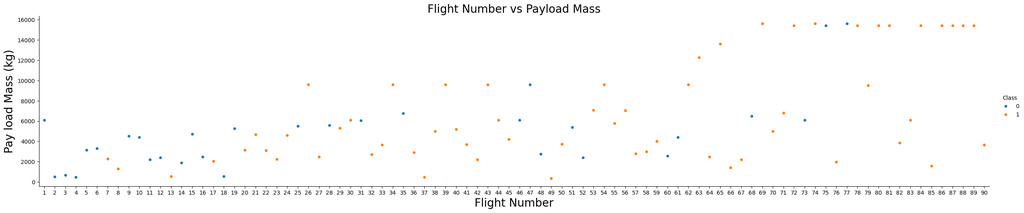

```python
sns.catplot(y="PayloadMass", x="FlightNumber", hue="Class", data=df, aspect = 5)
plt.xlabel("Flight Number",fontsize=20)
plt.ylabel("Pay load Mass (kg)",fontsize=20)
plt.title("Flight Number vs Payload Mass", fontsize=20)
plt.show()
```

#### Flight Number vs Launch Site

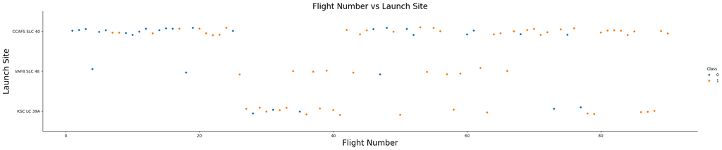

```python
sns.catplot(y="LaunchSite", x="FlightNumber", hue="Class", data=df, aspect = 5)
plt.xlabel("Flight Number",fontsize=20)
plt.ylabel("Launch Site",fontsize=20)
plt.title("Flight Number vs Launch Site", fontsize=20)
plt.show()
```

#### Payload Mass vs Launch Site

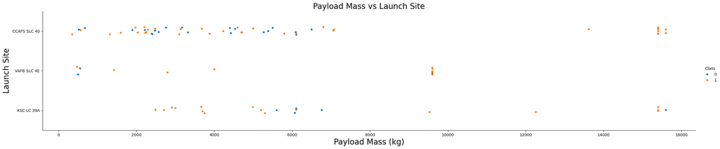

```python
sns.catplot(y="LaunchSite", x="PayloadMass", hue="Class", data=df, aspect = 5)
plt.xlabel("Payload Mass (kg)",fontsize=20)
plt.ylabel("Launch Site",fontsize=20)
plt.title("Payload Mass vs Launch Site", fontsize=20)
plt.show()
```

#### Success of Launches by Orbit

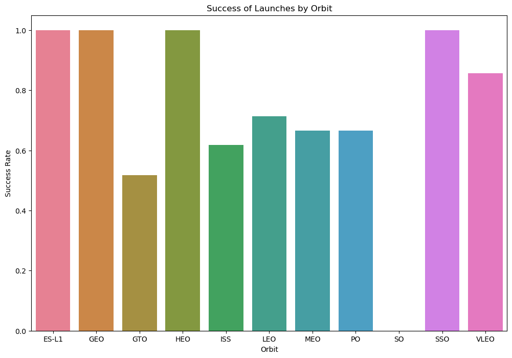

```python
dd=df.groupby(['Orbit'])['Class'].mean().reset_index()

# Create the grouped bar chart using seaborn
plt.figure(figsize=(12, 8))
sns.barplot(x='Orbit', y='Class', hue='Orbit', data=dd)
plt.xlabel('Orbit')
plt.ylabel('Success Rate')
plt.title('Success of Launches by Orbit')
plt.savefig("Bar_Chart.png")
plt.show()
```

```python
# Verify SO
df[df['Orbit']=='SO'].head()
```

|  | FlightNumber | Date | BoosterVersion | PayloadMass | Orbit | LaunchSite | Outcome | Flights | GridFins | Reused | Legs | LandingPad | Block | ReusedCount | Serial | Longitude | Latitude | Class |
| --- | --- | --- | --- | --- | --- | --- | --- | --- | --- | --- | --- | --- | --- | --- | --- | --- | --- | --- |
| 72 | 73 | 2020-01-19 | Falcon 9 | 6104.959412 | SO | KSC LC 39A | None None | 4 | False | True | False | NaN | 5.0 | 3 | B1046 | -80.603956 | 28.608058 | 0 |

#### Flight Number vs Orbit

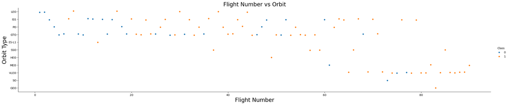

```python
sns.catplot(y="Orbit", x="FlightNumber", hue="Class", data=df, aspect = 5)
plt.xlabel("Flight Number",fontsize=20)
plt.ylabel("Orbit Type",fontsize=20)
plt.title("Flight Number vs Orbit", fontsize=20)
plt.show()
```

#### Payload Mass vs Orbit

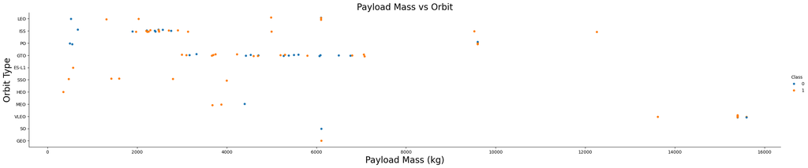

```python
sns.catplot(y="Orbit", x="PayloadMass", hue="Class", data=df, aspect = 5)
plt.xlabel("Payload Mass (kg)",fontsize=20)
plt.ylabel("Orbit Type",fontsize=20)
plt.title("Payload Mass vs Orbit", fontsize=20)
plt.show()
```

#### Average Landing Success Rate by Year

**Creating a function to swap date for year only**

```python
# A function to Extract years from the date
year=[]
def Extract_year():
    for i in df["Date"]:
        year.append(i.split("-")[0])
    return
Extract_year()
df['Date'] = year
df.head()
```

|  | FlightNumber | Date | BoosterVersion | PayloadMass | Orbit | LaunchSite | Outcome | Flights | GridFins | Reused | Legs | LandingPad | Block | ReusedCount | Serial | Longitude | Latitude | Class |
| --- | --- | --- | --- | --- | --- | --- | --- | --- | --- | --- | --- | --- | --- | --- | --- | --- | --- | --- |
| 0 | 1 | 2010 | Falcon 9 | 6104.959412 | LEO | CCAFS SLC 40 | None None | 1 | False | False | False | NaN | 1.0 | 0 | B0003 | -80.577366 | 28.561857 | 0 |
| 1 | 2 | 2012 | Falcon 9 | 525.000000 | LEO | CCAFS SLC 40 | None None | 1 | False | False | False | NaN | 1.0 | 0 | B0005 | -80.577366 | 28.561857 | 0 |
| 2 | 3 | 2013 | Falcon 9 | 677.000000 | ISS | CCAFS SLC 40 | None None | 1 | False | False | False | NaN | 1.0 | 0 | B0007 | -80.577366 | 28.561857 | 0 |
| 3 | 4 | 2013 | Falcon 9 | 500.000000 | PO | VAFB SLC 4E | False Ocean | 1 | False | False | False | NaN | 1.0 | 0 | B1003 | -120.610829 | 34.632093 | 0 |
| 4 | 5 | 2013 | Falcon 9 | 3170.000000 | GTO | CCAFS SLC 40 | None None | 1 | False | False | False | NaN | 1.0 | 0 | B1004 | -80.577366 | 28.561857 | 0 |

**Use new Year column to plot success rate**

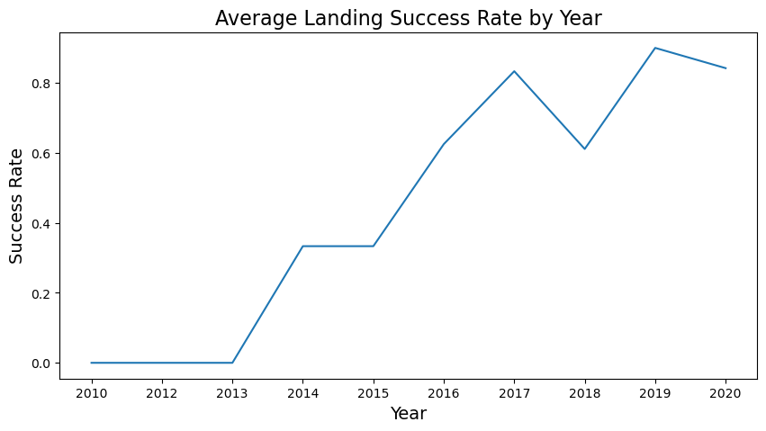

```python
dd=df.groupby(['Date'])['Class'].mean().reset_index()

plt.figure(figsize=(10, 5))
sns.lineplot(data=dd, x='Date', y='Class')
plt.title("Average Landing Success Rate by Year", fontsize=16)
plt.xlabel("Year",fontsize=14)
plt.ylabel("Success Rate",fontsize=14)
plt.show()
```

## B: DV Folium Map for Launches

- Using icons, tooltip label hover, polylines, markers & marker clusters

Note on Folium Markers

Each run stacks marker. Mistakes or changes will all be stacked on top of each other. If making detailed map with many features, work on map copy for each feature then add to map 1 time after proven to function.

#### Imports

```python
import folium
import pandas as pd
```

MarkerCluster MousePosition - for visible lat,long DivIcon - permanent marker

```python
from folium.plugins import MarkerCluster
from folium.plugins import MousePosition
from folium.features import DivIcon
```

#### DF

```python
URL = r'https://cf-courses-data.s3.us.cloud-object-storage.appdomain.cloud/IBM-DS0321EN-SkillsNetwork/datasets/spacex_launch_geo.csv'
spacex_df=pd.read_csv(URL)
spacex_df.head(2)
```

|  | Flight Number | Date | Time (UTC) | Booster Version | Launch Site | Payload | Payload Mass (kg) | Orbit | Customer | Landing Outcome | class | Lat | Long |
| --- | --- | --- | --- | --- | --- | --- | --- | --- | --- | --- | --- | --- | --- |
| 0 | 1 | 2010-06-04 | 18:45:00 | F9 v1.0 B0003 | CCAFS LC-40 | Dragon Spacecraft Qualification Unit | 0.0 | LEO | SpaceX | Failure (parachute) | 0 | 28.562302 | -80.577356 |
| 1 | 2 | 2010-12-08 | 15:43:00 | F9 v1.0 B0004 | CCAFS LC-40 | Dragon demo flight C1, two CubeSats, barrel of Brouère cheese | 0.0 | LEO (ISS) | NASA (COTS) NRO | Failure (parachute) | 0 | 28.562302 | -80.577356 |

**Subset**

```python
spacex_df = spacex_df[['Launch Site', 'Lat', 'Long', 'class']]
launch_sites_df = spacex_df.groupby(['Launch Site'], as_index=False).first()
launch_sites_df = launch_sites_df[['Launch Site', 'Lat', 'Long']]
launch_sites_df
```

|  | Launch Site | Lat | Long |
| --- | --- | --- | --- |
| 0 | CCAFS LC-40 | 28.562302 | -80.577356 |
| 1 | CCAFS SLC-40 | 28.563197 | -80.576820 |
| 2 | KSC LC-39A | 28.573255 | -80.646895 |
| 3 | VAFB SLC-4E | 34.632834 | -120.610745 |

#### Map Starting Point @ NASA Johnshon Space Center Houston,TX

- Add Circle
- Add Icon

Map object, with an initial center location to be NASA Johnson Space Center at Houston, Texas.

```python
# Start location is NASA Johnson Space Center
nasa_coordinate = [29.559684888503615, -95.0830971930759]
site_map = folium.Map(location=nasa_coordinate, zoom_start=10)
```

Adding Cirle with Popup & DivIcon

- for reference g.search(py fol circ, py fol divIcon, etc...)
- font 12 (small) is different from 12pt (big)

```python
# Create a blue circle at NASA Johnson Space Center's coordinate with a popup label showing its name
circle = folium.Circle(nasa_coordinate, radius=1000, color='#d35400', fill=True).add_child(folium.Popup('NASA Johnson Space Center'))
# Create a blue circle at NASA Johnson Space Center's coordinate with a icon showing its name
marker = folium.map.Marker(
    nasa_coordinate,
    # Create an icon as a text label
    icon=DivIcon(
        icon_size=(20,20),
        icon_anchor=(0,0),
        html=f"""<div style="font-size: 12; color:#d35400;"><b>NASA JSC</b></div>""",
        )
    )
site_map.add_child(circle)
site_map.add_child(marker)
```

Make this Notebook Trusted to load map: File -> Trust Notebook

[interactive chart not shown]

Make this Notebook Trusted to load map: File -> Trust Notebook

[interactive chart not shown]

### Add Launch Sites

- Tooltip for hover display of marker label name

```python
m = site_map
```

```python
# Initial the map
site_map = folium.Map(location=nasa_coordinate, zoom_start=4)
# For each launch site, add a Circle object based on its coordinate (Lat, Long) values. In addition, add Launch site name as a popup label

# instantiate a feature group for the Launch_Sites in the dataframe
Launch_Sites = folium.map.FeatureGroup()

# Add each to the launch sites feature group
for lat, long, label in zip(launch_sites_df.Lat, launch_sites_df.Long, launch_sites_df["Launch Site"]):
    Launch_Sites.add_child(
        folium.vector_layers.CircleMarker(
            [lat, long],
            radius=5, # define how big you want the circle markers to be
            color='yellow',
            fill=True,
            tooltip=label,
            fill_color='blue',
            fill_opacity=0.6
        )
    )

# add Launch Sites to map
site_map.add_child(Launch_Sites)
```

```
<folium.map.FeatureGroup at 0x20bc5b505c0>
```

[output not shown]

[output not shown]

[output not shown]

Make this Notebook Trusted to load map: File -> Trust Notebook

[interactive chart not shown]

### Marker Cluster Success/Fail at each Site

- Adding color coding (green = success, red = failure), map column to column based on condition
- Marker is clickable showing flight number
- new iterrow() function for marker maker

```python
spacex_df.tail(2)
```

|  | Launch Site | Lat | Long | class |
| --- | --- | --- | --- | --- |
| 54 | CCAFS SLC-40 | 28.563197 | -80.57682 | 1 |
| 55 | CCAFS SLC-40 | 28.563197 | -80.57682 | 0 |

Add Color Code column

- 3 ways to map: np(done here), lambda(tried if else broken), pure py(next lab)

```python
import numpy as np
spacex_df['marker_color'] = np.where(
    spacex_df['class'] == 1, "green", "red")
spacex_df.tail(2)
```

|  | Launch Site | Lat | Long | class | marker_color |
| --- | --- | --- | --- | --- | --- |
| 54 | CCAFS SLC-40 | 28.563197 | -80.57682 | 1 | green |
| 55 | CCAFS SLC-40 | 28.563197 | -80.57682 | 0 | red |

**Marker Cluster**

```python
m = site_map
```

```python
marker_cluster = MarkerCluster()
```

```python
# Add marker_cluster to current site_map
site_map.add_child(marker_cluster)

# for each row in spacex_df data frame
# create a Marker object with its coordinate
# and customize the Marker's icon property to indicate if this launch was successed or failed,
# e.g., icon=folium.Icon(color='white', icon_color=row['marker_color']
for index, record in spacex_df.iterrows():
    # TODO: Create and add a Marker cluster to the site map
    # marker = folium.Marker(...)
    marker = folium.Marker(
        location=[record['Lat'],record['Long']],
        icon=folium.Icon(color='white', icon_color=record['marker_color']),
        popup=f"Flight Number: {index}"
    )
    marker_cluster.add_child(marker)

site_map
```

Make this Notebook Trusted to load map: File -> Trust Notebook

[interactive chart not shown]

[output not shown]

[output not shown]

[output not shown]

[output not shown]

[output not shown]

[output not shown]

[output not shown]

[output not shown]

[output not shown]

[output not shown]

[output not shown]

[output not shown]

[output not shown]

[output not shown]

[output not shown]

[output not shown]

[output not shown]

[output not shown]

[output not shown]

[output not shown]

[output not shown]

[output not shown]

[output not shown]

[output not shown]

[output not shown]

[output not shown]

[output not shown]

[output not shown]

[output not shown]

[output not shown]

[output not shown]

[output not shown]

[output not shown]

[output not shown]

[output not shown]

[output not shown]

[output not shown]

[output not shown]

[output not shown]

[output not shown]

[output not shown]

[output not shown]

[output not shown]

[output not shown]

[output not shown]

[output not shown]

[output not shown]

[output not shown]

[output not shown]

[output not shown]

[output not shown]

[output not shown]

[output not shown]

[output not shown]

[output not shown]

[output not shown]

Make this Notebook Trusted to load map: File -> Trust Notebook

[interactive chart not shown]

```python
site_map
```

Make this Notebook Trusted to load map: File -> Trust Notebook

[interactive chart not shown]

### Distance to Proximities

- use mouse position to manually take lat, long data
- use distance function for lat, long (rad) to calc d
- label proximity and draw polyline
- Ex. distance to coastline

Make a Lat, Long mouse position box on top-right For Later: make click and save to list option

```python
# Add Mouse Position to get the coordinate (Lat, Long) for a mouse over on the map
formatter = "function(num) {return L.Util.formatNum(num, 5);};"
mouse_position = MousePosition(
    position='topright',
    separator=' Long: ',
    empty_string='NaN',
    lng_first=False,
    num_digits=20,
    prefix='Lat:',
    lat_formatter=formatter,
    lng_formatter=formatter,
)

site_map.add_child(mouse_position)
site_map
```

Make this Notebook Trusted to load map: File -> Trust Notebook

[interactive chart not shown]

Make this Notebook Trusted to load map: File -> Trust Notebook

[interactive chart not shown]

**Distance Function**

```python
from math import sin, cos, sqrt, atan2, radians

def calculate_distance(lat1, lon1, lat2, lon2):
    # approximate radius of earth in km
    R = 6373.0

    lat1 = radians(lat1)
    lon1 = radians(lon1)
    lat2 = radians(lat2)
    lon2 = radians(lon2)

    dlon = lon2 - lon1
    dlat = lat2 - lat1

    a = sin(dlat / 2)**2 + cos(lat1) * cos(lat2) * sin(dlon / 2)**2
    c = 2 * atan2(sqrt(a), sqrt(1 - a))

    distance = R * c
    return distance
```

**Coastline Distance**

```python
# find coordinate of the closet coastline
# e.g.,: Lat: 28.56367  Lon: -80.57163
# distance_coastline = calculate_distance(launch_site_lat, launch_site_lon, coastline_lat, coastline_lon)
c_lat = 34.63408
c_lon = -120.62563
VAFB_lat = 34.6328
VAFB_lon = -120.6107
distance_coastline = calculate_distance(VAFB_lat, VAFB_lon, c_lat, c_lon)
distance_coastline
```

```
1.3737976252792368
```

Adding distance as DivIcon DivIcon HTML formatted slightly different this time Icons are good for Landmark names and circling Areas, Here it looks funky, would use a marker with "click for distance" type label...

```python
# Create and add a folium.Marker on your selected closest coastline point on the map
# Display the distance between coastline point and launch site using the icon property
# for example
distance_marker = folium.Marker(
   [c_lat,c_lon],
   popup=distance_coastline,
   icon=DivIcon(
       icon_size=(20,20),
       icon_anchor=(0,0),
       html='<div style="font-size: 12; color:#d35400;"><b>%s</b></div>' % "{:10.2f} KM".format(distance_coastline),
       )
   ).add_to(site_map)
```

```python
site_map
```

Make this Notebook Trusted to load map: File -> Trust Notebook

[interactive chart not shown]

#### Draw Polyline to Coast

- [caution] every edit re-run stacks lines

```python
m = site_map
```

```python
# Create a `folium.PolyLine` object using the coastline coordinates and launch site coordinate
# lines=folium.PolyLine(locations=coordinates, weight=1)
line = folium.PolyLine([[VAFB_lat, VAFB_lon],[ c_lat, c_lon]], color='blue', weight=5, opacity=0.8)
site_map.add_child(line)
```

Make this Notebook Trusted to load map: File -> Trust Notebook

[interactive chart not shown]

## C: DV Launch Success Record Dashboard

- 2 inputs (dropdown, slider) , 2 outputs (g.pie, g.scatter)
- Test bench for code to be used in Dash
- Dash code script, screenshot of example outputs

### Test Bench for Dash code

```python
path = r"C:\Users\EngPh\OneDrive\Desktop\Data Science\C10 DS Capstone SpaceX\M3 Folium Maps and Dashboard\spacex_launch_dash.csv"
df=pd.read_csv(path)
df.head(3)
```

|  | Unnamed: 0 | Flight Number | Launch Site | class | Payload Mass (kg) | Booster Version | Booster Version Category |
| --- | --- | --- | --- | --- | --- | --- | --- |
| 0 | 0 | 1 | CCAFS LC-40 | 0 | 0.0 | F9 v1.0 B0003 | v1.0 |
| 1 | 1 | 2 | CCAFS LC-40 | 0 | 0.0 | F9 v1.0 B0004 | v1.0 |
| 2 | 2 | 3 | CCAFS LC-40 | 0 | 525.0 | F9 v1.0 B0005 | v1.0 |

```python
df['Booster Version Category'].value_counts()
```

```
Booster Version Category
FT      24
v1.1    15
B4      11
v1.0     5
B5       1
Name: count, dtype: int64
```

```python
df.groupby('Booster Version Category')['class'].sum().reset_index()
```

|  | Booster Version Category | class |
| --- | --- | --- |
| 0 | B4 | 6 |
| 1 | B5 | 1 |
| 2 | FT | 16 |
| 3 | v1.0 | 0 |
| 4 | v1.1 | 1 |

```python
df.groupby('Booster Version Category')['class'].mean().reset_index()
```

|  | Booster Version Category | class |
| --- | --- | --- |
| 0 | B4 | 0.545455 |
| 1 | B5 | 1.000000 |
| 2 | FT | 0.666667 |
| 3 | v1.0 | 0.000000 |
| 4 | v1.1 | 0.066667 |

```python
df['Launch Site'].value_counts()
```

```
Launch Site
CCAFS LC-40     26
KSC LC-39A      13
VAFB SLC-4E     10
CCAFS SLC-40     7
Name: count, dtype: int64
```

```python
df['class'].value_counts()
```

```
class
0    32
1    24
Name: count, dtype: int64
```

```python
df2 = df[df['Launch Site']=="CCAFS LC-40"]
df2.info
```

```
<bound method DataFrame.info of     Unnamed: 0  Flight Number  Launch Site  class  Payload Mass (kg)  \
0            0              1  CCAFS LC-40      0                0.0
1            1              2  CCAFS LC-40      0                0.0
2            2              3  CCAFS LC-40      0              525.0
3            3              4  CCAFS LC-40      0              500.0
4            4              5  CCAFS LC-40      0              677.0
5            5              7  CCAFS LC-40      0             3170.0
6            6              8  CCAFS LC-40      0             3325.0
7            7              9  CCAFS LC-40      0             2296.0
8            8             10  CCAFS LC-40      0             1316.0
9            9             11  CCAFS LC-40      0             4535.0
10          10             12  CCAFS LC-40      0             4428.0
11          11             13  CCAFS LC-40      0             2216.0
12          12             14  CCAFS LC-40      0             2395.0
13          13             15  CCAFS LC-40      0              570.0
```

[output cut: 40 more lines]

#### Handy: python mapping

- plotly charts are finnicky about changing data names vs changing traces names, so needed extra column

```python
df['Outcome'] = df['class'].map({1: 'Successful', 0: 'Unsuccessful'})
df.head(3)
```

|  | Unnamed: 0 | Flight Number | Launch Site | class | Payload Mass (kg) | Booster Version | Booster Version Category | Outcome |
| --- | --- | --- | --- | --- | --- | --- | --- | --- |
| 0 | 0 | 1 | CCAFS LC-40 | 0 | 0.0 | F9 v1.0 B0003 | v1.0 | Unsuccessful |
| 1 | 1 | 2 | CCAFS LC-40 | 0 | 0.0 | F9 v1.0 B0004 | v1.0 | Unsuccessful |
| 2 | 2 | 3 | CCAFS LC-40 | 0 | 525.0 | F9 v1.0 B0005 | v1.0 | Unsuccessful |

### Dash Script

- Graph functions: 2 cases All data, or site data, can select payload range as well

Notes:  
When grouping by count, can create "Count" column with reset_index()  
Mapped a new column directly with map() function, needed for legend name change display  
Did some name formatting with " {}".format()  
Group mean() and sum() functions work better with reset_index()  
Color options 3 ways: 1 would need color column, 2 didn't work, 3 direct (done here)  
Built conditional mask for DF in g.scatter function

#### Installs, Files, Execution Code for Theia

python3.11 -m pip install pandas dash

wget "https://cf-courses-data.s3.us.cloud-object-storage.appdomain.cloud/IBM-DS0321EN-SkillsNetwork/datasets/spacex_launch_dash.csv"

wget "https://cf-courses-data.s3.us.cloud-object-storage.appdomain.cloud/IBM-DS0321EN-SkillsNetwork/labs/module_3/spacex_dash_app.py"

python3.11 spacex_dash_app.py

#### Code for IBM Cloud IDE - based on Eclipse Theia open source

```python
# Import required libraries
import pandas as pd
import dash
import dash_html_components as html
import dash_core_components as dcc
from dash.dependencies import Input, Output
import plotly.express as px

# Read the airline data into pandas dataframe
spacex_df = pd.read_csv("spacex_launch_dash.csv")
max_payload = spacex_df['Payload Mass (kg)'].max()
min_payload = spacex_df['Payload Mass (kg)'].min()

# Create a dash application
app = dash.Dash(__name__)

# Create an app layout
app.layout = html.Div(children=[html.H1('SpaceX Launch Records Dashboard',
                                        style={'textAlign': 'center', 'color': '#503D36',
                                               'font-size': 40}),
                                # TASK 1: Add a dropdown list to enable Launch Site selection
                                # The default select value is for ALL sites
                                # dcc.Dropdown(id='site-dropdown',...)
                                  dcc.Dropdown(id='site-dropdown',
                                              options=[
                                                  {'label': 'All Sites', 'value': 'ALL'},
                                                  {'label': 'CCAFS LC-40', 'value': 'CCAFS LC-40'},
                                                  {'label': 'VAFB SLC-4E', 'value': 'VAFB SLC-4E'},
                                                  {'label': 'KSC LC-39A', 'value': 'KSC LC-39A'},
                                                  {'label': 'CCAFS SLC-40', 'value': 'CCAFS SLC-40'},
                                              ],
                                              value='ALL',
                                              placeholder="All Launch Sites",
                                              searchable=True
                                              ),
                                html.Br(),

                                # TASK 2: Add a pie chart to show the total successful launches count for all sites
                                # If a specific launch site was selected, show the Success vs. Failed counts for the site
                                html.Div(dcc.Graph(id='success-pie-chart')),
                                html.Br(),

                                html.P("Payload range (Kg):"),
                                # TASK 3: Add a slider to select payload range
                                #dcc.RangeSlider(id='payload-slider',...)
                                dcc.RangeSlider(id='payload-slider',
                                                min=0, max=10000, step=1000,
                                                value=[min_payload, max_payload]),
                                html.Br(),

                                # TASK 4: Add a scatter chart to show the correlation between payload and launch success
                                html.Div(dcc.Graph(id='success-payload-scatter-chart')),
                                ])

# TASK 2:
# Add a callback function for `site-dropdown` as input, `success-pie-chart` as output

# Function decorator to specify function input and output
@app.callback(Output(component_id='success-pie-chart', component_property='figure'),
              Input(component_id='site-dropdown', component_property='value'))
def get_pie_chart(entered_site):
    # subset data
    site_df = spacex_df[spacex_df['Launch Site']==entered_site]
    site_df = site_df.groupby('class').size().reset_index(name='Count')
    # add column for labels
    site_df['Outcome'] = site_df['class'].map({1: 'Successful', 0: 'Unsuccessful'})
    # group totals
    All_df = spacex_df.groupby('Launch Site')['class'].sum().reset_index()
    if entered_site == 'ALL':
        fig = px.pie(All_df, values='class',
        names='Launch Site',
        title='Successful Landings by Launch Site')
        return fig
    else:
        fig = px.pie(site_df, values='Count',
        names='Outcome',
        color_discrete_sequence = ['lightsteelblue','limegreen'],
        title="Successful Landings at {}".format(entered_site))
        return fig
        # return the outcomes piechart for a selected site

# TASK 4:
# Add a callback function for `site-dropdown` and `payload-slider` as inputs, `success-payload-scatter-chart` as output

@app.callback(Output(component_id='success-payload-scatter-chart', component_property='figure'),
              [Input(component_id='site-dropdown', component_property='value'),Input(component_id='payload-slider', component_property='value')])

def get_scatter_chart(entered_site, entered_payload_range):
    site_df2 = spacex_df[spacex_df['Launch Site']==entered_site]
    All_df = spacex_df.groupby('Launch Site')['class'].sum().reset_index()
    if entered_site == 'ALL':
        low, high = entered_payload_range
        mask = (spacex_df['Payload Mass (kg)'] > low) & (spacex_df['Payload Mass (kg)'] < high)
        fig = px.scatter(spacex_df[mask], x="Payload Mass (kg)", y="class", color="Booster Version Category",
                         hover_data=['Payload Mass (kg)'], title='Launch Success by Payload and Booster')
        return fig
    else:
        low, high = entered_payload_range
        mask = (site_df2['Payload Mass (kg)'] > low) & (site_df2['Payload Mass (kg)'] < high)
        fig = px.scatter(site_df2[mask], x="Payload Mass (kg)", y="class", color="Booster Version Category",
                         hover_data=['Payload Mass (kg)'], title="Launch Success at {} by Payload and Booster".format(entered_site))
        return fig


# Run the app
if __name__ == '__main__':
    app.run_server()
```

#### Plot 1: All sites and Full range of payloads selected

#### Plot 2: Specific site and specific payload range selected

[figure not shown]

[figure not shown]

# 4 ML Classification Predictive Analysis

- Use numerical matrix all categorical variables hot-coded
- Preprocess with Standard Scaler
- Train Test Split and Cross Validation
- Confusion Matrix Model Evaluation
- Classification Models: Logistic Regression, Support Vector Machine, Decision Tree, K-Nearest Neighbors
- GridSearch CV to find optimal model with optimal parameters

### Prep DF for Model Analysis

#### Imports

```python
import pandas as pd
import numpy as np
import matplotlib.pyplot as plt
import seaborn as sns
from sklearn import preprocessing
from sklearn.model_selection import train_test_split
from sklearn.model_selection import GridSearchCV
from sklearn.linear_model import LogisticRegression
from sklearn.svm import SVC
from sklearn.tree import DecisionTreeClassifier
from sklearn.neighbors import KNeighborsClassifier
```

#### Functions

```python
def plot_confusion_matrix(y,y_predict):
    "this function plots the confusion matrix"
    from sklearn.metrics import confusion_matrix

    cm = confusion_matrix(y, y_predict)
    ax= plt.subplot()
    sns.heatmap(cm, annot=True, ax = ax); #annot=True to annotate cells
    ax.set_xlabel('Predicted labels')
    ax.set_ylabel('True labels')
    ax.set_title('Confusion Matrix');
    ax.xaxis.set_ticklabels(['did not land', 'land']); ax.yaxis.set_ticklabels(['did not land', 'landed'])
    plt.show()
```

#### DF

```python
URL1 = r"https://cf-courses-data.s3.us.cloud-object-storage.appdomain.cloud/IBM-DS0321EN-SkillsNetwork/datasets/dataset_part_2.csv"
data = pd.read_csv(URL1)
data.head()
```

|  | FlightNumber | Date | BoosterVersion | PayloadMass | Orbit | LaunchSite | Outcome | Flights | GridFins | Reused | Legs | LandingPad | Block | ReusedCount | Serial | Longitude | Latitude | Class |
| --- | --- | --- | --- | --- | --- | --- | --- | --- | --- | --- | --- | --- | --- | --- | --- | --- | --- | --- |
| 0 | 1 | 2010-06-04 | Falcon 9 | 6104.959412 | LEO | CCAFS SLC 40 | None None | 1 | False | False | False | NaN | 1.0 | 0 | B0003 | -80.577366 | 28.561857 | 0 |
| 1 | 2 | 2012-05-22 | Falcon 9 | 525.000000 | LEO | CCAFS SLC 40 | None None | 1 | False | False | False | NaN | 1.0 | 0 | B0005 | -80.577366 | 28.561857 | 0 |
| 2 | 3 | 2013-03-01 | Falcon 9 | 677.000000 | ISS | CCAFS SLC 40 | None None | 1 | False | False | False | NaN | 1.0 | 0 | B0007 | -80.577366 | 28.561857 | 0 |
| 3 | 4 | 2013-09-29 | Falcon 9 | 500.000000 | PO | VAFB SLC 4E | False Ocean | 1 | False | False | False | NaN | 1.0 | 0 | B1003 | -120.610829 | 34.632093 | 0 |
| 4 | 5 | 2013-12-03 | Falcon 9 | 3170.000000 | GTO | CCAFS SLC 40 | None None | 1 | False | False | False | NaN | 1.0 | 0 | B1004 | -80.577366 | 28.561857 | 0 |

```python
data.columns
```

```
Index(['FlightNumber', 'Date', 'BoosterVersion', 'PayloadMass', 'Orbit',
       'LaunchSite', 'Outcome', 'Flights', 'GridFins', 'Reused', 'Legs',
       'LandingPad', 'Block', 'ReusedCount', 'Serial', 'Longitude', 'Latitude',
       'Class'],
      dtype='object')
```

**Hot-Coded DF**

```python
URL2 = r'https://cf-courses-data.s3.us.cloud-object-storage.appdomain.cloud/IBM-DS0321EN-SkillsNetwork/datasets/dataset_part_3.csv'
X = pd.read_csv(URL2)
X.head(100)
```

|  | FlightNumber | PayloadMass | Flights | Block | ReusedCount | Orbit_ES-L1 | Orbit_GEO | Orbit_GTO | Orbit_HEO | Orbit_ISS | ... | Serial_B1058 | Serial_B1059 | Serial_B1060 | Serial_B1062 | GridFins_False | GridFins_True | Reused_False | Reused_True | Legs_False | Legs_True |
| --- | --- | --- | --- | --- | --- | --- | --- | --- | --- | --- | --- | --- | --- | --- | --- | --- | --- | --- | --- | --- | --- |
| 0 | 1.0 | 6104.959412 | 1.0 | 1.0 | 0.0 | 0.0 | 0.0 | 0.0 | 0.0 | 0.0 | ... | 0.0 | 0.0 | 0.0 | 0.0 | 1.0 | 0.0 | 1.0 | 0.0 | 1.0 | 0.0 |
| 1 | 2.0 | 525.000000 | 1.0 | 1.0 | 0.0 | 0.0 | 0.0 | 0.0 | 0.0 | 0.0 | ... | 0.0 | 0.0 | 0.0 | 0.0 | 1.0 | 0.0 | 1.0 | 0.0 | 1.0 | 0.0 |
| 2 | 3.0 | 677.000000 | 1.0 | 1.0 | 0.0 | 0.0 | 0.0 | 0.0 | 0.0 | 1.0 | ... | 0.0 | 0.0 | 0.0 | 0.0 | 1.0 | 0.0 | 1.0 | 0.0 | 1.0 | 0.0 |
| 3 | 4.0 | 500.000000 | 1.0 | 1.0 | 0.0 | 0.0 | 0.0 | 0.0 | 0.0 | 0.0 | ... | 0.0 | 0.0 | 0.0 | 0.0 | 1.0 | 0.0 | 1.0 | 0.0 | 1.0 | 0.0 |
| 4 | 5.0 | 3170.000000 | 1.0 | 1.0 | 0.0 | 0.0 | 0.0 | 1.0 | 0.0 | 0.0 | ... | 0.0 | 0.0 | 0.0 | 0.0 | 1.0 | 0.0 | 1.0 | 0.0 | 1.0 | 0.0 |
| ... | ... | ... | ... | ... | ... | ... | ... | ... | ... | ... | ... | ... | ... | ... | ... | ... | ... | ... | ... | ... | ... |
| 85 | 86.0 | 15400.000000 | 2.0 | 5.0 | 2.0 | 0.0 | 0.0 | 0.0 | 0.0 | 0.0 | ... | 0.0 | 0.0 | 1.0 | 0.0 | 0.0 | 1.0 | 0.0 | 1.0 | 0.0 | 1.0 |
| 86 | 87.0 | 15400.000000 | 3.0 | 5.0 | 2.0 | 0.0 | 0.0 | 0.0 | 0.0 | 0.0 | ... | 1.0 | 0.0 | 0.0 | 0.0 | 0.0 | 1.0 | 0.0 | 1.0 | 0.0 | 1.0 |
| 87 | 88.0 | 15400.000000 | 6.0 | 5.0 | 5.0 | 0.0 | 0.0 | 0.0 | 0.0 | 0.0 | ... | 0.0 | 0.0 | 0.0 | 0.0 | 0.0 | 1.0 | 0.0 | 1.0 | 0.0 | 1.0 |
| 88 | 89.0 | 15400.000000 | 3.0 | 5.0 | 2.0 | 0.0 | 0.0 | 0.0 | 0.0 | 0.0 | ... | 0.0 | 0.0 | 1.0 | 0.0 | 0.0 | 1.0 | 0.0 | 1.0 | 0.0 | 1.0 |
| 89 | 90.0 | 3681.000000 | 1.0 | 5.0 | 0.0 | 0.0 | 0.0 | 0.0 | 0.0 | 0.0 | ... | 0.0 | 0.0 | 0.0 | 1.0 | 0.0 | 1.0 | 1.0 | 0.0 | 0.0 | 1.0 |

90 rows × 83 columns

**Target Array**

```python
Y = data['Class'].to_numpy()
Y[:3]
```

```
array([0, 0, 0], dtype=int64)
```

**Standardize Feature Matrix**

```python
X = preprocessing.StandardScaler().fit(X).transform(X.astype(float))
X[0:5]
```

```
array([[-1.71291154e+00, -1.94814463e-16, -6.53912840e-01,
        -1.57589457e+00, -9.73440458e-01, -1.05999788e-01,
        -1.05999788e-01, -6.54653671e-01, -1.05999788e-01,
        -5.51677284e-01,  3.44342023e+00, -1.85695338e-01,
        -3.33333333e-01, -1.05999788e-01, -2.42535625e-01,
        -4.29197538e-01,  7.97724035e-01, -5.68796459e-01,
        -4.10890702e-01, -4.10890702e-01, -1.50755672e-01,
        -7.97724035e-01, -1.50755672e-01, -3.92232270e-01,
         9.43398113e+00, -1.05999788e-01, -1.05999788e-01,
        -1.05999788e-01, -1.05999788e-01, -1.05999788e-01,
        -1.05999788e-01, -1.05999788e-01, -1.05999788e-01,
        -1.05999788e-01, -1.05999788e-01, -1.05999788e-01,
        -1.05999788e-01, -1.05999788e-01, -1.05999788e-01,
        -1.05999788e-01, -1.05999788e-01, -1.05999788e-01,
        -1.05999788e-01, -1.50755672e-01, -1.05999788e-01,
        -1.05999788e-01, -1.05999788e-01, -1.05999788e-01,
        -1.05999788e-01, -1.50755672e-01, -1.05999788e-01,
        -1.50755672e-01, -1.50755672e-01, -1.05999788e-01,
        -1.50755672e-01, -1.50755672e-01, -1.05999788e-01,
        -1.05999788e-01, -1.50755672e-01, -1.50755672e-01,
        -1.50755672e-01, -1.05999788e-01, -1.05999788e-01,
        -1.05999788e-01, -1.50755672e-01, -2.15665546e-01,
        -1.85695338e-01, -2.15665546e-01, -2.67261242e-01,
        -1.05999788e-01, -2.42535625e-01, -1.05999788e-01,
        -2.15665546e-01, -1.85695338e-01, -2.15665546e-01,
        -1.85695338e-01, -1.05999788e-01,  1.87082869e+00,
        -1.87082869e+00,  8.35531692e-01, -8.35531692e-01,
         1.93309133e+00, -1.93309133e+00],
       [-1.67441914e+00, -1.19523159e+00, -6.53912840e-01,
        -1.57589457e+00, -9.73440458e-01, -1.05999788e-01,
        -1.05999788e-01, -6.54653671e-01, -1.05999788e-01,
        -5.51677284e-01,  3.44342023e+00, -1.85695338e-01,
        -3.33333333e-01, -1.05999788e-01, -2.42535625e-01,
        -4.29197538e-01,  7.97724035e-01, -5.68796459e-01,
        -4.10890702e-01, -4.10890702e-01, -1.50755672e-01,
        -7.97724035e-01, -1.50755672e-01, -3.92232270e-01,
        -1.05999788e-01,  9.43398113e+00, -1.05999788e-01,
        -1.05999788e-01, -1.05999788e-01, -1.05999788e-01,
        -1.05999788e-01, -1.05999788e-01, -1.05999788e-01,
        -1.05999788e-01, -1.05999788e-01, -1.05999788e-01,
```

[output cut: 85 more lines]

```
        -1.05999788e-01, -1.05999788e-01, -1.05999788e-01,
        -1.05999788e-01, -1.50755672e-01, -1.05999788e-01,
        -1.05999788e-01, -1.05999788e-01, -1.05999788e-01,
        -1.05999788e-01, -1.50755672e-01, -1.05999788e-01,
        -1.50755672e-01, -1.50755672e-01, -1.05999788e-01,
        -1.50755672e-01, -1.50755672e-01, -1.05999788e-01,
        -1.05999788e-01, -1.50755672e-01, -1.50755672e-01,
        -1.50755672e-01, -1.05999788e-01, -1.05999788e-01,
        -1.05999788e-01, -1.50755672e-01, -2.15665546e-01,
        -1.85695338e-01, -2.15665546e-01, -2.67261242e-01,
        -1.05999788e-01, -2.42535625e-01, -1.05999788e-01,
        -2.15665546e-01, -1.85695338e-01, -2.15665546e-01,
        -1.85695338e-01, -1.05999788e-01,  1.87082869e+00,
        -1.87082869e+00,  8.35531692e-01, -8.35531692e-01,
         1.93309133e+00, -1.93309133e+00]])
```

#### Train/Test Split

```python
X_train, X_test, Y_train, Y_test = train_test_split(X, Y, test_size=0.2, random_state=2)
print ('Train set:', X_train.shape,  Y_train.shape)
print ('Test set:', X_test.shape,  Y_test.shape)
```

```
Train set: (72, 83) (72,)
Test set: (18, 83) (18,)
```

### Model 1: Logistic Regression with GridSearch CV

```python
# `C` is hyperparameter for fitting usually 10^-2 to 10^3 type, penalty l1 lasso l2 ridge, solver lbfgs is quasi-Newton Hessian matrix kind
parameters ={"C":[0.01,0.1,1],'penalty':['l2'], 'solver':['lbfgs']}
lr=LogisticRegression()
```

Fit GridSearchCV to training data

- model, parameters, crossfold val

```python
logreg_cv = GridSearchCV(lr, parameters,cv=10)
logreg_cv.fit(X_train, Y_train)
```

```
GridSearchCV(cv=10, estimator=LogisticRegression(),
             param_grid={'C': [0.01, 0.1, 1], 'penalty': ['l2'],
                         'solver': ['lbfgs']})
```

Best Paramaters and Best Score on training data

```python
print("tuned hpyerparameters :(best parameters) ",logreg_cv.best_params_)
print("accuracy :",logreg_cv.best_score_)
```

```
tuned hpyerparameters :(best parameters)  {'C': 0.01, 'penalty': 'l2', 'solver': 'lbfgs'}
accuracy : 0.8464285714285713
```

Best test score

```python
logreg_cv.score(X_test, Y_test)
```

```
0.8333333333333334
```

Confusion Matrix to test Predictions

```python
yhat=logreg_cv.predict(X_test)
plot_confusion_matrix(Y_test,yhat)
```

[output not shown]

### Model 2: Support Vector Machine with GridSearchCV

- Repeating all steps
- Minor change to model dependent parameters

```python
parameters = {'kernel':('linear', 'rbf','poly','rbf', 'sigmoid'),
              'C': np.logspace(-3, 3, 5),
              'gamma':np.logspace(-3, 3, 5)}
svm = SVC()
```

```python
svm_cv = GridSearchCV(svm, parameters,cv=10)
svm_cv.fit(X_train, Y_train)
```

```
GridSearchCV(cv=10, estimator=SVC(),
             param_grid={'C': array([1.00000000e-03, 3.16227766e-02, 1.00000000e+00, 3.16227766e+01,
       1.00000000e+03]),
                         'gamma': array([1.00000000e-03, 3.16227766e-02, 1.00000000e+00, 3.16227766e+01,
       1.00000000e+03]),
                         'kernel': ('linear', 'rbf', 'poly', 'rbf', 'sigmoid')})
```

```python
print("tuned hpyerparameters :(best parameters) ",svm_cv.best_params_)
print("accuracy :",svm_cv.best_score_)
```

```
tuned hpyerparameters :(best parameters)  {'C': 1.0, 'gamma': 0.03162277660168379, 'kernel': 'sigmoid'}
accuracy : 0.8482142857142856
```

```python
svm_cv.score(X_test, Y_test)
```

```
0.8333333333333334
```

```python
yhat=svm_cv.predict(X_test)
plot_confusion_matrix(Y_test,yhat)
```

[output not shown]

### Model 3: Decision Tree Classification with GridSearchCV

- Repeat, adjusting paramters to model

```python
parameters = {'criterion': ['gini', 'entropy'],
     'splitter': ['best', 'random'],
     'max_depth': [2*n for n in range(1,10)],
     'max_features': ['auto', 'sqrt'],
     'min_samples_leaf': [1, 2, 4],
     'min_samples_split': [2, 5, 10]}

tree = DecisionTreeClassifier()
```

```python
# Does not like that there are still NaN values in dataset
```

```python
tree_cv = GridSearchCV(tree, parameters,cv=10)
tree_cv.fit(X_train, Y_train)
```

[output not shown]

[output cut: 74 more lines]

[output not shown]

```
GridSearchCV(cv=10, estimator=DecisionTreeClassifier(),
             param_grid={'criterion': ['gini', 'entropy'],
                         'max_depth': [2, 4, 6, 8, 10, 12, 14, 16, 18],
                         'max_features': ['auto', 'sqrt'],
                         'min_samples_leaf': [1, 2, 4],
                         'min_samples_split': [2, 5, 10],
                         'splitter': ['best', 'random']})
```

```python
print("tuned hpyerparameters :(best parameters) ",tree_cv.best_params_)
print("accuracy :",tree_cv.best_score_)
```

```
tuned hpyerparameters :(best parameters)  {'criterion': 'entropy', 'max_depth': 4, 'max_features': 'sqrt', 'min_samples_leaf': 2, 'min_samples_split': 10, 'splitter': 'random'}
accuracy : 0.8892857142857142
```

```python
# 1st go had same best train score, but test score was .833 par like all else
```

```python
tree_cv.score(X_test, Y_test)
```

```
0.7222222222222222
```

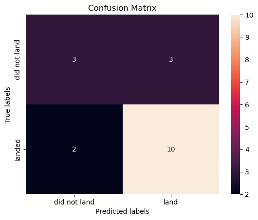

```python
yhat = tree_cv.predict(X_test)
plot_confusion_matrix(Y_test,yhat)
```

### Model 4: K-Nearest Neighbors with GridSearchCV

```python
parameters = {'n_neighbors': [1, 2, 3, 4, 5, 6, 7, 8, 9, 10],
              'algorithm': ['auto', 'ball_tree', 'kd_tree', 'brute'],
              'p': [1,2]}

KNN = KNeighborsClassifier()
```

```python
knn_cv = GridSearchCV(KNN, parameters,cv=10)
knn_cv.fit(X_train, Y_train)
```

```
GridSearchCV(cv=10, estimator=KNeighborsClassifier(),
             param_grid={'algorithm': ['auto', 'ball_tree', 'kd_tree', 'brute'],
                         'n_neighbors': [1, 2, 3, 4, 5, 6, 7, 8, 9, 10],
                         'p': [1, 2]})
```

```python
print("tuned hpyerparameters :(best parameters) ",knn_cv.best_params_)
print("accuracy :",knn_cv.best_score_)
```

```
tuned hpyerparameters :(best parameters)  {'algorithm': 'auto', 'n_neighbors': 10, 'p': 1}
accuracy : 0.8482142857142858
```

```python
# Best `n` is always going to be max, will never tell you elbow point, could remove to speed up calcs on large datasets
```

```python
knn_cv.score(X_test, Y_test)
```

```
0.8333333333333334
```

```python
yhat = knn_cv.predict(X_test)
plot_confusion_matrix(Y_test,yhat)
```

[output not shown]

```python
# Need to go back and save scores with the following names for bar chart to work
data = {"Model": ["Log_Reg", "SVM", "D_Tree", "KNN_10"], "Score": [LogReg, SVM, D_Tree, KNN_10]}

# Create the bar plot
plt.figure(figsize=(10, 4))
sns.barplot(x='Model', y='Score', hue='Model', data=data)
plt.xlabel('Model')
plt.ylabel('Prediction Score')
plt.title('R^2 Score by Model')
plt.savefig("Score_Bar_Chart.png")
plt.show()
```

[output not shown]

### Note:

# 5 Presenting Data Driven Insights

### Full data report Powerpoint of findings

- https://github.com/DLPhysics/DS-Projects/blob/main/Data%20Science%20Capstone%20SpaceX%20Launches%20_%20Complete.pdf